# UKB - Heteroplasmy, CHIP, and MN

# 5 Supplementary Table 3 - Sensitivity analyses for the associations of heteroplasmy, CHIP, and MN.

## 5.1 Restricted to self-reported White individuals

```r
# Number of participants
ukb |>
  filter(race_new == "white") |>
  summarise(participants = n())
```

```
##   participants
## 1       410313
```

```r
# Heteroplasmy vs. CHIP
m1 <- survival::coxph(surv ~ het_chip + rms::rcs(age, 5) + sex + smk_ever + prev_cancer_yn, data = ukb, subset = race_new == "white")
summary(m1)
```

```
## Call:
## survival::coxph(formula = surv ~ het_chip + rms::rcs(age, 5) +
##     sex + smk_ever + prev_cancer_yn, data = ukb, subset = race_new ==
##     "white")
##
##   n= 410313, number of events= 1157
##
##                            coef exp(coef) se(coef)      z Pr(>|z|)
## het_chiphet only        0.53958   1.71528  0.07645  7.058 1.69e-12 ***
## het_chipchip only       1.69559   5.44986  0.08670 19.558  < 2e-16 ***
## het_chipboth            2.51015  12.30683  0.08080 31.068  < 2e-16 ***
## rms::rcs(age, 5)age     0.05684   1.05848  0.03601  1.578   0.1145
## rms::rcs(age, 5)age'    0.10161   1.10695  0.11141  0.912   0.3618
## rms::rcs(age, 5)age''  -0.57825   0.56088  0.42659 -1.356   0.1753
## rms::rcs(age, 5)age'''  1.58239   4.86656  0.78547  2.015   0.0439 *
## sexmen                  0.40060   1.49272  0.05972  6.708 1.98e-11 ***
## smk_everyes             0.13901   1.14913  0.06291  2.210   0.0271 *
## prev_cancer_yn          0.13990   1.15016  0.09756  1.434   0.1516
## ---
## Signif. codes:  0 '***' 0.001 '**' 0.01 '*' 0.05 '.' 0.1 ' ' 1
##
##                        exp(coef) exp(-coef) lower .95 upper .95
## het_chiphet only          1.7153    0.58299    1.4766     1.993
## het_chipchip only         5.4499    0.18349    4.5982     6.459
## het_chipboth             12.3068    0.08126   10.5044    14.418
## rms::rcs(age, 5)age       1.0585    0.94475    0.9864     1.136
## rms::rcs(age, 5)age'      1.1070    0.90338    0.8898     1.377
## rms::rcs(age, 5)age''     0.5609    1.78292    0.2431     1.294
## rms::rcs(age, 5)age'''    4.8666    0.20548    1.0438    22.689
## sexmen                    1.4927    0.66992    1.3278     1.678
## smk_everyes               1.1491    0.87022    1.0158     1.300
## prev_cancer_yn            1.1502    0.86944    0.9500     1.393
##
## Concordance= 0.761  (se = 0.008 )
## Likelihood ratio test= 1404  on 10 df,   p=<2e-16
## Wald test            = 1670  on 10 df,   p=<2e-16
## Score (logrank) test = 2534  on 10 df,   p=<2e-16
```

```r
m1_table_w <-
  summary(m1)$coefficients[c(1:3), c(1:3, 5)] |>
  as.data.frame() |>
  mutate(character = "white") |>
  rownames_to_column("variable")

# Heteroplasmy metrics
m2 <- survival::coxph(surv ~ count_het + mMSS + rms::rcs(age, 5) + sex + smk_ever + prev_cancer_yn, data = ukb, subset = race_new == "white")
summary(m2)
```

```
## Call:
## survival::coxph(formula = surv ~ count_het + mMSS + rms::rcs(age,
##     5) + sex + smk_ever + prev_cancer_yn, data = ukb, subset = race_new ==
##     "white")
##
##   n= 410313, number of events= 1157
##
##                            coef exp(coef) se(coef)      z Pr(>|z|)
## count_het               0.26939   1.30916  0.04312  6.248 4.16e-10 ***
## mMSS                    1.26461   3.54171  0.10648 11.877  < 2e-16 ***
## rms::rcs(age, 5)age     0.06247   1.06446  0.03604  1.733   0.0830 .
## rms::rcs(age, 5)age'    0.10156   1.10690  0.11146  0.911   0.3622
## rms::rcs(age, 5)age''  -0.56629   0.56763  0.42669 -1.327   0.1845
## rms::rcs(age, 5)age'''  1.53728   4.65190  0.78559  1.957   0.0504 .
## sexmen                  0.37303   1.45213  0.05975  6.243 4.30e-10 ***
## smk_everyes             0.14677   1.15809  0.06295  2.332   0.0197 *
## prev_cancer_yn          0.15061   1.16255  0.09757  1.544   0.1227
## ---
## Signif. codes:  0 '***' 0.001 '**' 0.01 '*' 0.05 '.' 0.1 ' ' 1
##
##                        exp(coef) exp(-coef) lower .95 upper .95
## count_het                 1.3092     0.7638    1.2031     1.425
## mMSS                      3.5417     0.2823    2.8746     4.364
## rms::rcs(age, 5)age       1.0645     0.9394    0.9919     1.142
## rms::rcs(age, 5)age'      1.1069     0.9034    0.8897     1.377
## rms::rcs(age, 5)age''     0.5676     1.7617    0.2460     1.310
## rms::rcs(age, 5)age'''    4.6519     0.2150    0.9975    21.693
## sexmen                    1.4521     0.6886    1.2916     1.633
## smk_everyes               1.1581     0.8635    1.0237     1.310
## prev_cancer_yn            1.1625     0.8602    0.9602     1.408
##
## Concordance= 0.723  (se = 0.008 )
## Likelihood ratio test= 859.4  on 9 df,   p=<2e-16
## Wald test            = 1067  on 9 df,   p=<2e-16
## Score (logrank) test = 1316  on 9 df,   p=<2e-16
```

```r
m2_table_w <-
  summary(m2)$coefficients[c(1:2), c(1:3, 5)] |>
  as.data.frame() |>
  mutate(character = "white") |>
  rownames_to_column("variable")

# CHRS category
ukb_chip |>
  filter(race_new == "white") |>
  summarise(participants = n())
```

```
##   participants
## 1        32066
```

```r
m3 <- survival::coxph(surv_chip ~ chrs_cat + rms::rcs(age, 5) + sex + smk_ever + prev_cancer_yn, data = ukb_chip, subset = race_new == "white")
summary(m3)
```

```
## Call:
## survival::coxph(formula = surv_chip ~ chrs_cat + rms::rcs(age,
##     5) + sex + smk_ever + prev_cancer_yn, data = ukb_chip, subset = race_new ==
##     "white")
##
##   n= 32066, number of events= 450
##
##                            coef exp(coef) se(coef)      z Pr(>|z|)
## chrs_catintermediate    2.29211   9.89579  0.10864 21.099  < 2e-16 ***
## chrs_cathigh            4.40281  81.67998  0.13762 31.993  < 2e-16 ***
## rms::rcs(age, 5)age     0.17819   1.19505  0.06374  2.796  0.00518 **
## rms::rcs(age, 5)age'   -0.11652   0.89001  0.13390 -0.870  0.38418
## rms::rcs(age, 5)age''  -0.30630   0.73617  0.79399 -0.386  0.69967
## rms::rcs(age, 5)age'''  3.29487  26.97391  2.34034  1.408  0.15917
## sexmen                  0.21732   1.24274  0.09856  2.205  0.02745 *
## smk_everyes             0.01845   1.01863  0.10327  0.179  0.85817
## prev_cancer_yn         -0.33470   0.71555  0.16668 -2.008  0.04464 *
## ---
## Signif. codes:  0 '***' 0.001 '**' 0.01 '*' 0.05 '.' 0.1 ' ' 1
##
##                        exp(coef) exp(-coef) lower .95 upper .95
## chrs_catintermediate      9.8958    0.10105    7.9979    12.244
## chrs_cathigh             81.6800    0.01224   62.3700   106.968
## rms::rcs(age, 5)age       1.1950    0.83679    1.0547     1.354
## rms::rcs(age, 5)age'      0.8900    1.12358    0.6846     1.157
## rms::rcs(age, 5)age''     0.7362    1.35839    0.1553     3.490
## rms::rcs(age, 5)age'''   26.9739    0.03707    0.2747  2648.774
## sexmen                    1.2427    0.80467    1.0244     1.508
## smk_everyes               1.0186    0.98171    0.8320     1.247
## prev_cancer_yn            0.7156    1.39753    0.5161     0.992
##
## Concordance= 0.799  (se = 0.012 )
## Likelihood ratio test= 1013  on 9 df,   p=<2e-16
## Wald test            = 1389  on 9 df,   p=<2e-16
## Score (logrank) test = 4718  on 9 df,   p=<2e-16
```

```r
m3_table_w <-
  summary(m3)$coefficients[c(1:2), c(1:3, 5)] |>
  as.data.frame() |>
  mutate(character = "white") |>
  rownames_to_column("variable")
```

## 5.2 Restricted to self-reported non-White individuals

```r
# Number of participants
ukb |>
  filter(race_new != "white") |>
  summarise(participants = n())
```

```
##   participants
## 1        23991
```

```r
# Heteroplasmy vs. CHIP
m1 <- survival::coxph(surv ~ het_chip + rms::rcs(age, 5) + sex + smk_ever + prev_cancer_yn, data = ukb, subset = race_new != "white")
summary(m1)
```

```
## Call:
## survival::coxph(formula = surv ~ het_chip + rms::rcs(age, 5) +
##     sex + smk_ever + prev_cancer_yn, data = ukb, subset = race_new !=
##     "white")
##
##   n= 23991, number of events= 34
##
##                              coef  exp(coef)   se(coef)      z Pr(>|z|)
## het_chiphet only        5.266e-01  1.693e+00  3.987e-01  1.321 0.186648
## het_chipchip only       8.933e-01  2.443e+00  6.287e-01  1.421 0.155331
## het_chipboth            1.866e+00  6.462e+00  5.642e-01  3.307 0.000942 ***
## rms::rcs(age, 5)age     8.184e-02  1.085e+00  1.233e-01  0.664 0.506955
## rms::rcs(age, 5)age'   -4.775e-01  6.203e-01  4.779e-01 -0.999 0.317739
## rms::rcs(age, 5)age''   3.076e+00  2.166e+01  2.130e+00  1.444 0.148780
## rms::rcs(age, 5)age''' -8.393e+00  2.265e-04  4.677e+00 -1.795 0.072723 .
## sexmen                  1.542e-01  1.167e+00  3.551e-01  0.434 0.664111
## smk_everyes            -3.867e-01  6.793e-01  3.702e-01 -1.044 0.296268
## prev_cancer_yn         -1.684e+01  4.843e-08  3.753e+03 -0.004 0.996419
## ---
## Signif. codes:  0 '***' 0.001 '**' 0.01 '*' 0.05 '.' 0.1 ' ' 1
##
##                        exp(coef) exp(-coef) lower .95 upper .95
## het_chiphet only       1.693e+00  5.906e-01 7.750e-01     3.699
## het_chipchip only      2.443e+00  4.093e-01 7.126e-01     8.377
## het_chipboth           6.462e+00  1.548e-01 2.138e+00    19.525
## rms::rcs(age, 5)age    1.085e+00  9.214e-01 8.522e-01     1.382
## rms::rcs(age, 5)age'   6.203e-01  1.612e+00 2.431e-01     1.583
## rms::rcs(age, 5)age''  2.166e+01  4.616e-02 3.331e-01  1408.897
## rms::rcs(age, 5)age''' 2.265e-04  4.415e+03 2.367e-08     2.167
## sexmen                 1.167e+00  8.571e-01 5.817e-01     2.340
## smk_everyes            6.793e-01  1.472e+00 3.288e-01     1.403
## prev_cancer_yn         4.843e-08  2.065e+07 0.000e+00       Inf
##
## Concordance= 0.734  (se = 0.048 )
## Likelihood ratio test= 28.54  on 10 df,   p=0.001
## Wald test            = 31.94  on 10 df,   p=4e-04
## Score (logrank) test = 40.26  on 10 df,   p=2e-05
```

```r
m1_table_nw <-
  summary(m1)$coefficients[c(1:3), c(1:3, 5)] |>
  as.data.frame() |>
  mutate(character = "non-white") |>
  rownames_to_column("variable")

# Heteroplasmy metrics
m2 <- survival::coxph(surv ~ count_het + mMSS + rms::rcs(age, 5) + sex + smk_ever + prev_cancer_yn, data = ukb, subset = race_new != "white")
summary(m2)
```

```
## Call:
## survival::coxph(formula = surv ~ count_het + mMSS + rms::rcs(age,
##     5) + sex + smk_ever + prev_cancer_yn, data = ukb, subset = race_new !=
##     "white")
##
##   n= 23991, number of events= 34
##
##                              coef  exp(coef)   se(coef)      z Pr(>|z|)
## count_het               3.757e-01  1.456e+00  2.637e-01  1.424  0.15430
## mMSS                    1.605e+00  4.976e+00  6.137e-01  2.615  0.00893 **
## rms::rcs(age, 5)age     8.205e-02  1.086e+00  1.234e-01  0.665  0.50598
## rms::rcs(age, 5)age'   -4.739e-01  6.225e-01  4.762e-01 -0.995  0.31959
## rms::rcs(age, 5)age''   3.048e+00  2.107e+01  2.119e+00  1.439  0.15024
## rms::rcs(age, 5)age''' -8.355e+00  2.353e-04  4.653e+00 -1.796  0.07256 .
## sexmen                  1.988e-01  1.220e+00  3.556e-01  0.559  0.57599
## smk_everyes            -4.021e-01  6.689e-01  3.711e-01 -1.083  0.27860
## prev_cancer_yn         -1.633e+01  8.121e-08  2.483e+03 -0.007  0.99475
## ---
## Signif. codes:  0 '***' 0.001 '**' 0.01 '*' 0.05 '.' 0.1 ' ' 1
##
##                        exp(coef) exp(-coef) lower .95 upper .95
## count_het              1.456e+00  6.868e-01 8.683e-01     2.441
## mMSS                   4.976e+00  2.009e-01 1.495e+00    16.570
## rms::rcs(age, 5)age    1.086e+00  9.212e-01 8.524e-01     1.382
## rms::rcs(age, 5)age'   6.225e-01  1.606e+00 2.448e-01     1.583
## rms::rcs(age, 5)age''  2.107e+01  4.745e-02 3.314e-01  1340.235
## rms::rcs(age, 5)age''' 2.353e-04  4.250e+03 2.577e-08     2.149
## sexmen                 1.220e+00  8.197e-01 6.077e-01     2.449
## smk_everyes            6.689e-01  1.495e+00 3.232e-01     1.384
## prev_cancer_yn         8.121e-08  1.231e+07 0.000e+00       Inf
##
## Concordance= 0.758  (se = 0.048 )
## Likelihood ratio test= 36.06  on 9 df,   p=4e-05
## Wald test            = 52.02  on 9 df,   p=4e-08
## Score (logrank) test = 64.96  on 9 df,   p=1e-10
```

```r
m2_table_nw <-
  summary(m2)$coefficients[c(1:2), c(1:3, 5)] |>
  as.data.frame() |>
  mutate(character = "non-white") |>
  rownames_to_column("variable")

# CHRS category
ukb_chip |>
  filter(race_new != "white") |>
  summarise(participants = n())
```

```
##   participants
## 1         1531
```

```r
m3 <- survival::coxph(surv_chip ~ chrs_cat + rms::rcs(age, 5) + sex + smk_ever + prev_cancer_yn, data = ukb_chip, subset = race_new != "white")
summary(m3)
```

```
## Call:
## survival::coxph(formula = surv_chip ~ chrs_cat + rms::rcs(age,
##     5) + sex + smk_ever + prev_cancer_yn, data = ukb_chip, subset = race_new !=
##     "white")
##
##   n= 1531, number of events= 7
##
##                              coef  exp(coef)   se(coef)       z Pr(>|z|)
## chrs_catintermediate    2.018e+00  7.525e+00  7.640e-01   2.642  0.00825 **
## chrs_cathigh            5.343e+00  2.092e+02  1.084e+00   4.931 8.18e-07 ***
## rms::rcs(age, 5)age     7.446e-01  2.106e+00  6.291e-02  11.836  < 2e-16 ***
## rms::rcs(age, 5)age'   -1.379e+00  2.519e-01  4.866e-02 -28.333  < 2e-16 ***
## rms::rcs(age, 5)age''   6.932e+00  1.024e+03  3.065e-01  22.617  < 2e-16 ***
## rms::rcs(age, 5)age''' -1.620e+01  9.255e-08  2.537e+00  -6.383 1.73e-10 ***
## sexmen                 -1.819e-01  8.337e-01  7.640e-01  -0.238  0.81182
## smk_everyes             3.002e-01  1.350e+00  7.640e-01   0.393  0.69437
## prev_cancer_yn         -1.689e+01  4.641e-08  5.340e+03  -0.003  0.99748
## ---
## Signif. codes:  0 '***' 0.001 '**' 0.01 '*' 0.05 '.' 0.1 ' ' 1
##
##                        exp(coef) exp(-coef) lower .95 upper .95
## chrs_catintermediate   7.525e+00  1.329e-01 1.683e+00 3.364e+01
## chrs_cathigh           2.092e+02  4.780e-03 2.502e+01 1.749e+03
## rms::rcs(age, 5)age    2.106e+00  4.749e-01 1.861e+00 2.382e+00
## rms::rcs(age, 5)age'   2.519e-01  3.969e+00 2.290e-01 2.771e-01
## rms::rcs(age, 5)age''  1.024e+03  9.762e-04 5.618e+02 1.868e+03
## rms::rcs(age, 5)age''' 9.255e-08  1.080e+07 6.408e-10 1.337e-05
## sexmen                 8.337e-01  1.199e+00 1.865e-01 3.727e+00
## smk_everyes            1.350e+00  7.407e-01 3.020e-01 6.036e+00
## prev_cancer_yn         4.641e-08  2.155e+07 0.000e+00       Inf
##
## Concordance= 0.81  (se = 0.083 )
## Likelihood ratio test= 17.19  on 9 df,   p=0.05
## Wald test            = 1527  on 9 df,   p=<2e-16
## Score (logrank) test = 76.77  on 9 df,   p=7e-13
```

```r
m3_table_nw <-
  summary(m3)$coefficients[c(1:2), c(1:3, 5)] |>
  as.data.frame() |>
  mutate(character = "non-white") |>
  rownames_to_column("variable")
```

## 5.3 Restricted to genetically unrelated individuals

```r
# Number of participants
ukb |>
  filter(unrelated == 1) |>
  summarise(participants = n())
```

```
##   participants
## 1       362132
```

```r
# Heteroplasmy vs. CHIP
m1 <- survival::coxph(surv ~ het_chip + rms::rcs(age, 5) + sex + smk_ever + prev_cancer_yn, data = ukb, subset = unrelated == 1)
summary(m1)
```

```
## Call:
## survival::coxph(formula = surv ~ het_chip + rms::rcs(age, 5) +
##     sex + smk_ever + prev_cancer_yn, data = ukb, subset = unrelated ==
##     1)
##
##   n= 362132, number of events= 1013
##    (374 observations deleted due to missingness)
##
##                            coef exp(coef) se(coef)      z Pr(>|z|)
## het_chiphet only        0.57443   1.77612  0.08160  7.040 1.93e-12 ***
## het_chipchip only       1.73233   5.65380  0.09239 18.749  < 2e-16 ***
## het_chipboth            2.53380  12.60129  0.08680 29.190  < 2e-16 ***
## rms::rcs(age, 5)age     0.04676   1.04788  0.03626  1.290   0.1972
## rms::rcs(age, 5)age'    0.12169   1.12940  0.11433  1.064   0.2871
## rms::rcs(age, 5)age''  -0.65543   0.51922  0.44279 -1.480   0.1388
## rms::rcs(age, 5)age'''  1.75073   5.75883  0.82838  2.113   0.0346 *
## sexmen                  0.39342   1.48205  0.06389  6.158 7.37e-10 ***
## smk_everyes             0.11608   1.12309  0.06665  1.742   0.0815 .
## prev_cancer_yn          0.10599   1.11181  0.10716  0.989   0.3226
## ---
## Signif. codes:  0 '***' 0.001 '**' 0.01 '*' 0.05 '.' 0.1 ' ' 1
##
##                        exp(coef) exp(-coef) lower .95 upper .95
## het_chiphet only          1.7761    0.56302    1.5136     2.084
## het_chipchip only         5.6538    0.17687    4.7173     6.776
## het_chipboth             12.6013    0.07936   10.6299    14.938
## rms::rcs(age, 5)age       1.0479    0.95431    0.9760     1.125
## rms::rcs(age, 5)age'      1.1294    0.88542    0.9027     1.413
## rms::rcs(age, 5)age''     0.5192    1.92597    0.2180     1.237
## rms::rcs(age, 5)age'''    5.7588    0.17365    1.1356    29.204
## sexmen                    1.4820    0.67474    1.3076     1.680
## smk_everyes               1.1231    0.89040    0.9856     1.280
## prev_cancer_yn            1.1118    0.89944    0.9012     1.372
##
## Concordance= 0.758  (se = 0.008 )
## Likelihood ratio test= 1235  on 10 df,   p=<2e-16
## Wald test            = 1475  on 10 df,   p=<2e-16
## Score (logrank) test = 2246  on 10 df,   p=<2e-16
```

```r
m1_table_unrel <-
  summary(m1)$coefficients[c(1:3), c(1:3, 5)] |>
  as.data.frame() |>
  mutate(character = "unrelated") |>
  rownames_to_column("variable")

# Heteroplasmy metrics
m2 <- survival::coxph(surv ~ count_het + mMSS + rms::rcs(age, 5) + sex + smk_ever + prev_cancer_yn, data = ukb, subset = unrelated == 1)
summary(m2)
```

```
## Call:
## survival::coxph(formula = surv ~ count_het + mMSS + rms::rcs(age,
##     5) + sex + smk_ever + prev_cancer_yn, data = ukb, subset = unrelated ==
##     1)
##
##   n= 362132, number of events= 1013
##    (374 observations deleted due to missingness)
##
##                            coef exp(coef) se(coef)      z Pr(>|z|)
## count_het               0.28280   1.32684  0.04587  6.166 7.01e-10 ***
## mMSS                    1.28900   3.62916  0.11338 11.368  < 2e-16 ***
## rms::rcs(age, 5)age     0.05325   1.05469  0.03629  1.467   0.1423
## rms::rcs(age, 5)age'    0.11864   1.12597  0.11435  1.038   0.2995
## rms::rcs(age, 5)age''  -0.63075   0.53219  0.44276 -1.425   0.1543
## rms::rcs(age, 5)age'''  1.68220   5.37739  0.82827  2.031   0.0423 *
## sexmen                  0.36505   1.44058  0.06392  5.711 1.12e-08 ***
## smk_everyes             0.12408   1.13211  0.06669  1.861   0.0628 .
## prev_cancer_yn          0.10828   1.11436  0.10717  1.010   0.3123
## ---
## Signif. codes:  0 '***' 0.001 '**' 0.01 '*' 0.05 '.' 0.1 ' ' 1
##
##                        exp(coef) exp(-coef) lower .95 upper .95
## count_het                 1.3268     0.7537    1.2128     1.452
## mMSS                      3.6292     0.2755    2.9060     4.532
## rms::rcs(age, 5)age       1.0547     0.9481    0.9823     1.132
## rms::rcs(age, 5)age'      1.1260     0.8881    0.8999     1.409
## rms::rcs(age, 5)age''     0.5322     1.8790    0.2235     1.268
## rms::rcs(age, 5)age'''    5.3774     0.1860    1.0606    27.265
## sexmen                    1.4406     0.6942    1.2709     1.633
## smk_everyes               1.1321     0.8833    0.9934     1.290
## prev_cancer_yn            1.1144     0.8974    0.9032     1.375
##
## Concordance= 0.723  (se = 0.008 )
## Likelihood ratio test= 760.5  on 9 df,   p=<2e-16
## Wald test            = 964.9  on 9 df,   p=<2e-16
## Score (logrank) test = 1188  on 9 df,   p=<2e-16
```

```r
m2_table_unrel <-
  summary(m2)$coefficients[c(1:2), c(1:3, 5)] |>
  as.data.frame() |>
  mutate(character = "unrelated") |>
  rownames_to_column("variable")

# CHRS category
ukb_chip |>
  filter(unrelated == 1) |>
  summarise(participants = n())
```

```
##   participants
## 1        27998
```

```r
m3 <- survival::coxph(surv_chip ~ chrs_cat + rms::rcs(age, 5) + sex + smk_ever + prev_cancer_yn, data = ukb_chip, subset = unrelated == 1)
summary(m3)
```

```
## Call:
## survival::coxph(formula = surv_chip ~ chrs_cat + rms::rcs(age,
##     5) + sex + smk_ever + prev_cancer_yn, data = ukb_chip, subset = unrelated ==
##     1)
##
##   n= 27998, number of events= 395
##    (43 observations deleted due to missingness)
##
##                            coef exp(coef) se(coef)      z Pr(>|z|)
## chrs_catintermediate    2.35004  10.48602  0.11644 20.182  < 2e-16 ***
## chrs_cathigh            4.46537  86.95300  0.14663 30.453  < 2e-16 ***
## rms::rcs(age, 5)age     0.21021   1.23394  0.07017  2.996  0.00274 **
## rms::rcs(age, 5)age'   -0.17740   0.83744  0.14523 -1.222  0.22189
## rms::rcs(age, 5)age''  -0.08871   0.91511  0.85538 -0.104  0.91740
## rms::rcs(age, 5)age'''  3.41324  30.36349  2.51291  1.358  0.17437
## sexmen                  0.19088   1.21031  0.10555  1.808  0.07055 .
## smk_everyes             0.03466   1.03526  0.10953  0.316  0.75170
## prev_cancer_yn         -0.29986   0.74093  0.17832 -1.682  0.09265 .
## ---
## Signif. codes:  0 '***' 0.001 '**' 0.01 '*' 0.05 '.' 0.1 ' ' 1
##
##                        exp(coef) exp(-coef) lower .95 upper .95
## chrs_catintermediate     10.4860    0.09537    8.3463    13.174
## chrs_cathigh             86.9530    0.01150   65.2339   115.903
## rms::rcs(age, 5)age       1.2339    0.81041    1.0754     1.416
## rms::rcs(age, 5)age'      0.8374    1.19411    0.6300     1.113
## rms::rcs(age, 5)age''     0.9151    1.09276    0.1712     4.893
## rms::rcs(age, 5)age'''   30.3635    0.03293    0.2205  4181.601
## sexmen                    1.2103    0.82623    0.9841     1.488
## smk_everyes               1.0353    0.96594    0.8353     1.283
## prev_cancer_yn            0.7409    1.34966    0.5224     1.051
##
## Concordance= 0.806  (se = 0.013 )
## Likelihood ratio test= 944.7  on 9 df,   p=<2e-16
## Wald test            = 1269  on 9 df,   p=<2e-16
## Score (logrank) test = 4509  on 9 df,   p=<2e-16
```

```r
m3_table_unrel <-
  summary(m3)$coefficients[c(1:2), c(1:3, 5)] |>
  as.data.frame() |>
  mutate(character = "unrelated") |>
  rownames_to_column("variable")
```

## 5.4 Restricted to never smokers

```r
# Number of participants
ukb |>
  filter(smk == "never") |>
  summarise(participants = n())
```

```
##   participants
## 1       238086
```

```r
# Heteroplasmy vs. CHIP
m1 <- survival::coxph(surv ~ het_chip + rms::rcs(age, 5) + sex + prev_cancer_yn, data = ukb, subset = smk == "never")
summary(m1)
```

```
## Call:
## survival::coxph(formula = surv ~ het_chip + rms::rcs(age, 5) +
##     sex + prev_cancer_yn, data = ukb, subset = smk == "never")
##
##   n= 238086, number of events= 530
##
##                            coef exp(coef) se(coef)      z Pr(>|z|)
## het_chiphet only        0.48625   1.62621  0.11220  4.334 1.47e-05 ***
## het_chipchip only       1.58773   4.89264  0.13175 12.051  < 2e-16 ***
## het_chipboth            2.56843  13.04528  0.11829 21.714  < 2e-16 ***
## rms::rcs(age, 5)age     0.08691   1.09080  0.04724  1.840   0.0658 .
## rms::rcs(age, 5)age'   -0.08280   0.92054  0.14997 -0.552   0.5809
## rms::rcs(age, 5)age''   0.34817   1.41647  0.58980  0.590   0.5550
## rms::rcs(age, 5)age''' -0.59652   0.55072  1.13256 -0.527   0.5984
## sexmen                  0.38921   1.47582  0.08697  4.475 7.63e-06 ***
## prev_cancer_yn          0.08046   1.08379  0.15123  0.532   0.5947
## ---
## Signif. codes:  0 '***' 0.001 '**' 0.01 '*' 0.05 '.' 0.1 ' ' 1
##
##                        exp(coef) exp(-coef) lower .95 upper .95
## het_chiphet only          1.6262    0.61493   1.30518     2.026
## het_chipchip only         4.8926    0.20439   3.77919     6.334
## het_chipboth             13.0453    0.07666  10.34590    16.449
## rms::rcs(age, 5)age       1.0908    0.91676   0.99434     1.197
## rms::rcs(age, 5)age'      0.9205    1.08632   0.68609     1.235
## rms::rcs(age, 5)age''     1.4165    0.70598   0.44583     4.500
## rms::rcs(age, 5)age'''    0.5507    1.81579   0.05983     5.070
## sexmen                    1.4758    0.67759   1.24452     1.750
## prev_cancer_yn            1.0838    0.92269   0.80578     1.458
##
## Concordance= 0.748  (se = 0.012 )
## Likelihood ratio test= 615.3  on 9 df,   p=<2e-16
## Wald test            = 770.8  on 9 df,   p=<2e-16
## Score (logrank) test = 1199  on 9 df,   p=<2e-16
```

```r
m1_table_ns <-
  summary(m1)$coefficients[c(1:3), c(1:3, 5)] |>
  as.data.frame() |>
  mutate(character = "never smoker") |>
  rownames_to_column("variable")

# Heteroplasmy metrics
m2 <- survival::coxph(surv ~ count_het + mMSS + rms::rcs(age, 5) + sex + prev_cancer_yn, data = ukb, subset = smk == "never")
summary(m2)
```

```
## Call:
## survival::coxph(formula = surv ~ count_het + mMSS + rms::rcs(age,
##     5) + sex + prev_cancer_yn, data = ukb, subset = smk == "never")
##
##   n= 238086, number of events= 530
##
##                            coef exp(coef) se(coef)      z Pr(>|z|)
## count_het               0.27954   1.32252  0.06460  4.327 1.51e-05 ***
## mMSS                    1.36161   3.90249  0.16554  8.225  < 2e-16 ***
## rms::rcs(age, 5)age     0.09299   1.09745  0.04729  1.966   0.0492 *
## rms::rcs(age, 5)age'   -0.08546   0.91809  0.14994 -0.570   0.5687
## rms::rcs(age, 5)age''   0.36788   1.44466  0.58928  0.624   0.5324
## rms::rcs(age, 5)age''' -0.64653   0.52386  1.13116 -0.572   0.5676
## sexmen                  0.36479   1.44022  0.08695  4.195 2.73e-05 ***
## prev_cancer_yn          0.09073   1.09497  0.15129  0.600   0.5487
## ---
## Signif. codes:  0 '***' 0.001 '**' 0.01 '*' 0.05 '.' 0.1 ' ' 1
##
##                        exp(coef) exp(-coef) lower .95 upper .95
## count_het                 1.3225     0.7561   1.16524     1.501
## mMSS                      3.9025     0.2562   2.82118     5.398
## rms::rcs(age, 5)age       1.0974     0.9112   1.00031     1.204
## rms::rcs(age, 5)age'      0.9181     1.0892   0.68431     1.232
## rms::rcs(age, 5)age''     1.4447     0.6922   0.45516     4.585
## rms::rcs(age, 5)age'''    0.5239     1.9089   0.05707     4.809
## sexmen                    1.4402     0.6943   1.21454     1.708
## prev_cancer_yn            1.0950     0.9133   0.81400     1.473
##
## Concordance= 0.715  (se = 0.012 )
## Likelihood ratio test= 374.5  on 8 df,   p=<2e-16
## Wald test            = 482.9  on 8 df,   p=<2e-16
## Score (logrank) test = 589  on 8 df,   p=<2e-16
```

```r
m2_table_ns <-
  summary(m2)$coefficients[c(1:2), c(1:3, 5)] |>
  as.data.frame() |>
  mutate(character = "never_smoker") |>
  rownames_to_column("variable")

# CHRS category
ukb_chip |>
  filter(smk == "never") |>
  summarise(participants = n())
```

```
##   participants
## 1        17122
```

```r
m3 <- survival::coxph(surv_chip ~ chrs_cat + rms::rcs(age, 5) + sex + prev_cancer_yn, data = ukb_chip, subset = smk == "never")
summary(m3)
```

```
## Call:
## survival::coxph(formula = surv_chip ~ chrs_cat + rms::rcs(age,
##     5) + sex + prev_cancer_yn, data = ukb_chip, subset = smk ==
##     "never")
##
##   n= 17122, number of events= 195
##
##                            coef exp(coef) se(coef)      z Pr(>|z|)
## chrs_catintermediate    2.26598   9.64060  0.16082 14.091   <2e-16 ***
## chrs_cathigh            4.46080  86.55681  0.21584 20.668   <2e-16 ***
## rms::rcs(age, 5)age     0.20606   1.22883  0.09403  2.191   0.0284 *
## rms::rcs(age, 5)age'   -0.14376   0.86609  0.19559 -0.735   0.4623
## rms::rcs(age, 5)age''   0.03050   1.03097  1.16409  0.026   0.9791
## rms::rcs(age, 5)age'''  0.94185   2.56471  3.52722  0.267   0.7895
## sexmen                  0.21417   1.23884  0.14618  1.465   0.1429
## prev_cancer_yn         -0.48258   0.61719  0.26344 -1.832   0.0670 .
## ---
## Signif. codes:  0 '***' 0.001 '**' 0.01 '*' 0.05 '.' 0.1 ' ' 1
##
##                        exp(coef) exp(-coef) lower .95 upper .95
## chrs_catintermediate      9.6406    0.10373  7.034243    13.213
## chrs_cathigh             86.5568    0.01155 56.699781   132.136
## rms::rcs(age, 5)age       1.2288    0.81379  1.022008     1.477
## rms::rcs(age, 5)age'      0.8661    1.15461  0.590308     1.271
## rms::rcs(age, 5)age''     1.0310    0.96996  0.105286    10.095
## rms::rcs(age, 5)age'''    2.5647    0.38991  0.002551  2578.775
## sexmen                    1.2388    0.80721  0.930220     1.650
## prev_cancer_yn            0.6172    1.62026  0.368281     1.034
##
## Concordance= 0.793  (se = 0.018 )
## Likelihood ratio test= 417.1  on 8 df,   p=<2e-16
## Wald test            = 583  on 8 df,   p=<2e-16
## Score (logrank) test = 1996  on 8 df,   p=<2e-16
```

```r
m3_table_ns <-
  summary(m3)$coefficients[c(1:2), c(1:3, 5)] |>
  as.data.frame() |>
  mutate(character = "never smoker") |>
  rownames_to_column("variable")
```

## 5.5 Restricted to individuals without prevalent cancer.

```r
# Number of participants
ukb |>
  filter(prev_cancer_yn == 0) |>
  summarise(participants = n())
```

```
##   participants
## 1       403732
```

```r
# Heteroplasmy vs. CHIP
m1 <- survival::coxph(surv ~ het_chip + rms::rcs(age, 5) + sex + smk_ever, data = ukb, subset = prev_cancer_yn == 0)
summary(m1)
```

```
## Call:
## survival::coxph(formula = surv ~ het_chip + rms::rcs(age, 5) +
##     sex + smk_ever, data = ukb, subset = prev_cancer_yn == 0)
##
##   n= 403732, number of events= 1072
##
##                            coef exp(coef) se(coef)      z Pr(>|z|)
## het_chiphet only        0.53673   1.71040  0.07954  6.748 1.50e-11 ***
## het_chipchip only       1.71701   5.56784  0.08973 19.135  < 2e-16 ***
## het_chipboth            2.53022  12.55630  0.08404 30.107  < 2e-16 ***
## rms::rcs(age, 5)age     0.05501   1.05655  0.03551  1.549   0.1214
## rms::rcs(age, 5)age'    0.09344   1.09794  0.11166  0.837   0.4027
## rms::rcs(age, 5)age''  -0.48205   0.61752  0.43177 -1.116   0.2642
## rms::rcs(age, 5)age'''  1.24535   3.47415  0.80635  1.544   0.1225
## sexmen                  0.39756   1.48818  0.06213  6.399 1.57e-10 ***
## smk_everyes             0.12387   1.13187  0.06492  1.908   0.0564 .
## ---
## Signif. codes:  0 '***' 0.001 '**' 0.01 '*' 0.05 '.' 0.1 ' ' 1
##
##                        exp(coef) exp(-coef) lower .95 upper .95
## het_chiphet only          1.7104    0.58466    1.4635     1.999
## het_chipchip only         5.5678    0.17960    4.6699     6.638
## het_chipboth             12.5563    0.07964   10.6494    14.805
## rms::rcs(age, 5)age       1.0566    0.94647    0.9855     1.133
## rms::rcs(age, 5)age'      1.0979    0.91080    0.8821     1.367
## rms::rcs(age, 5)age''     0.6175    1.61938    0.2649     1.439
## rms::rcs(age, 5)age'''    3.4742    0.28784    0.7153    16.874
## sexmen                    1.4882    0.67196    1.3176     1.681
## smk_everyes               1.1319    0.88349    0.9966     1.285
##
## Concordance= 0.763  (se = 0.008 )
## Likelihood ratio test= 1338  on 9 df,   p=<2e-16
## Wald test            = 1595  on 9 df,   p=<2e-16
## Score (logrank) test = 2446  on 9 df,   p=<2e-16
```

```r
m1_table_cancer <-
  summary(m1)$coefficients[c(1:3), c(1:3, 5)] |>
  as.data.frame() |>
  mutate(character = "no cancer") |>
  rownames_to_column("variable")

# Heteroplasmy metrics
m2 <- survival::coxph(surv ~ count_het + mMSS + rms::rcs(age, 5) + sex + smk_ever, data = ukb, subset = prev_cancer_yn == 0)
summary(m2)
```

```
## Call:
## survival::coxph(formula = surv ~ count_het + mMSS + rms::rcs(age,
##     5) + sex + smk_ever, data = ukb, subset = prev_cancer_yn ==
##     0)
##
##   n= 403732, number of events= 1072
##
##                            coef exp(coef) se(coef)      z Pr(>|z|)
## count_het               0.22763   1.25562  0.04594  4.955 7.23e-07 ***
## mMSS                    1.39312   4.02741  0.11052 12.605  < 2e-16 ***
## rms::rcs(age, 5)age     0.06089   1.06279  0.03555  1.713   0.0867 .
## rms::rcs(age, 5)age'    0.09312   1.09760  0.11169  0.834   0.4044
## rms::rcs(age, 5)age''  -0.47101   0.62437  0.43183 -1.091   0.2754
## rms::rcs(age, 5)age'''  1.20856   3.34866  0.80665  1.498   0.1341
## sexmen                  0.37419   1.45382  0.06218  6.018 1.77e-09 ***
## smk_everyes             0.12840   1.13701  0.06500  1.975   0.0482 *
## ---
## Signif. codes:  0 '***' 0.001 '**' 0.01 '*' 0.05 '.' 0.1 ' ' 1
##
##                        exp(coef) exp(-coef) lower .95 upper .95
## count_het                 1.2556     0.7964    1.1475     1.374
## mMSS                      4.0274     0.2483    3.2430     5.001
## rms::rcs(age, 5)age       1.0628     0.9409    0.9913     1.139
## rms::rcs(age, 5)age'      1.0976     0.9111    0.8818     1.366
## rms::rcs(age, 5)age''     0.6244     1.6016    0.2678     1.456
## rms::rcs(age, 5)age'''    3.3487     0.2986    0.6890    16.274
## sexmen                    1.4538     0.6878    1.2870     1.642
## smk_everyes               1.1370     0.8795    1.0010     1.291
##
## Concordance= 0.726  (se = 0.008 )
## Likelihood ratio test= 833  on 8 df,   p=<2e-16
## Wald test            = 1056  on 8 df,   p=<2e-16
## Score (logrank) test = 1324  on 8 df,   p=<2e-16
```

```r
m2_table_cancer <-
  summary(m2)$coefficients[c(1:2), c(1:3, 5)] |>
  as.data.frame() |>
  mutate(character = "no cancer") |>
  rownames_to_column("variable")

# CHRS category
ukb_chip |>
  filter(prev_cancer_yn == 0) |>
  summarise(participants = n())
```

```
##   participants
## 1        30654
```

```r
m3 <- survival::coxph(surv_chip ~ chrs_cat + rms::rcs(age, 5) + sex + smk_ever, data = ukb_chip, subset = prev_cancer_yn == 0)
summary(m3)
```

```
## Call:
## survival::coxph(formula = surv_chip ~ chrs_cat + rms::rcs(age,
##     5) + sex + smk_ever, data = ukb_chip, subset = prev_cancer_yn ==
##     0)
##
##   n= 30654, number of events= 417
##
##                            coef exp(coef) se(coef)      z Pr(>|z|)
## chrs_catintermediate    2.34463  10.42944  0.11253 20.835  < 2e-16 ***
## chrs_cathigh            4.50693  90.64287  0.14342 31.425  < 2e-16 ***
## rms::rcs(age, 5)age     0.18458   1.20271  0.06411  2.879  0.00399 **
## rms::rcs(age, 5)age'   -0.11834   0.88839  0.13536 -0.874  0.38197
## rms::rcs(age, 5)age''  -0.33856   0.71280  0.80951 -0.418  0.67578
## rms::rcs(age, 5)age'''  3.36334  28.88541  2.41982  1.390  0.16456
## sexmen                  0.19505   1.21537  0.10285  1.896  0.05790 .
## smk_everyes             0.04193   1.04282  0.10727  0.391  0.69591
## ---
## Signif. codes:  0 '***' 0.001 '**' 0.01 '*' 0.05 '.' 0.1 ' ' 1
##
##                        exp(coef) exp(-coef) lower .95 upper .95
## chrs_catintermediate     10.4294    0.09588    8.3651    13.003
## chrs_cathigh             90.6429    0.01103   68.4313   120.064
## rms::rcs(age, 5)age       1.2027    0.83145    1.0607     1.364
## rms::rcs(age, 5)age'      0.8884    1.12563    0.6814     1.158
## rms::rcs(age, 5)age''     0.7128    1.40292    0.1459     3.484
## rms::rcs(age, 5)age'''   28.8854    0.03462    0.2517  3314.595
## sexmen                    1.2154    0.82280    0.9935     1.487
## smk_everyes               1.0428    0.95894    0.8451     1.287
##
## Concordance= 0.808  (se = 0.012 )
## Likelihood ratio test= 982.2  on 8 df,   p=<2e-16
## Wald test            = 1344  on 8 df,   p=<2e-16
## Score (logrank) test = 4892  on 8 df,   p=<2e-16
```

```r
m3_table_cancer <-
  summary(m3)$coefficients[c(1:2), c(1:3, 5)] |>
  as.data.frame() |>
  mutate(character = "no cancer") |>
  rownames_to_column("variable")
```

## 5.6 combine results

```r
table_w <-
  m1_table_w |>
  bind_rows(
    m2_table_w, m3_table_w
  )

table_nw <-
  m1_table_nw |>
  bind_rows(
    m2_table_nw, m3_table_nw
  )

table_unrel <-
  m1_table_unrel |>
  bind_rows(
    m2_table_unrel, m3_table_unrel
  )

table_ns <-
  m1_table_ns |>
  bind_rows(
    m2_table_ns, m3_table_ns
  )

table_cancer <-
  m1_table_cancer |>
  bind_rows(
    m2_table_cancer, m3_table_cancer
  )

table_sp3 <-
  bind_rows(
    table_w, table_nw, table_unrel, table_ns, table_cancer
  ) |>
  dplyr::select(character, everything())

# Write the data to the sheets
openxlsx::writeData(wb, sheet = "Supplementary Table 3", x = table_sp3)
```

# 6 Supplementary Figure 5 - Hazard ratios (95% confidence intervals) for the association between heteroplasmy and incident MN.

## 6.1 Panel A

```r
# Heteroplasmy count in categories
hc_cat <-
  survival::coxph(surv ~ count_het_cat + rms::rcs(age, 5) + sex + smk_ever + prev_cancer_yn, data = ukb)
summary(hc_cat)
```

```
## Call:
## survival::coxph(formula = surv ~ count_het_cat + rms::rcs(age,
##     5) + sex + smk_ever + prev_cancer_yn, data = ukb)
##
##   n= 434304, number of events= 1191
##
##                            coef exp(coef) se(coef)      z Pr(>|z|)
## count_het_cat1          0.55532   1.74249  0.06544  8.486  < 2e-16 ***
## count_het_cat2          1.03138   2.80492  0.09741 10.588  < 2e-16 ***
## count_het_cat3          1.71301   5.54563  0.15457 11.083  < 2e-16 ***
## count_het_cat4+         2.16928   8.75195  0.26155  8.294  < 2e-16 ***
## rms::rcs(age, 5)age     0.05960   1.06141  0.03430  1.737   0.0823 .
## rms::rcs(age, 5)age'    0.09857   1.10359  0.10745  0.917   0.3590
## rms::rcs(age, 5)age''  -0.50240   0.60508  0.41430 -1.213   0.2253
## rms::rcs(age, 5)age'''  1.31798   3.73588  0.76968  1.712   0.0868 .
## sexmen                  0.37107   1.44929  0.05887  6.304 2.91e-10 ***
## smk_everyes             0.14808   1.15960  0.06164  2.402   0.0163 *
## prev_cancer_yn          0.14819   1.15973  0.09744  1.521   0.1283
## ---
## Signif. codes:  0 '***' 0.001 '**' 0.01 '*' 0.05 '.' 0.1 ' ' 1
##
##                        exp(coef) exp(-coef) lower .95 upper .95
## count_het_cat1            1.7425     0.5739    1.5327     1.981
## count_het_cat2            2.8049     0.3565    2.3174     3.395
## count_het_cat3            5.5456     0.1803    4.0962     7.508
## count_het_cat4+           8.7519     0.1143    5.2417    14.613
## rms::rcs(age, 5)age       1.0614     0.9421    0.9924     1.135
## rms::rcs(age, 5)age'      1.1036     0.9061    0.8940     1.362
## rms::rcs(age, 5)age''     0.6051     1.6527    0.2686     1.363
## rms::rcs(age, 5)age'''    3.7359     0.2677    0.8265    16.887
## sexmen                    1.4493     0.6900    1.2914     1.627
## smk_everyes               1.1596     0.8624    1.0276     1.309
## prev_cancer_yn            1.1597     0.8623    0.9581     1.404
##
## Concordance= 0.717  (se = 0.007 )
## Likelihood ratio test= 775.6  on 11 df,   p=<2e-16
## Wald test            = 793.6  on 11 df,   p=<2e-16
## Score (logrank) test = 969.1  on 11 df,   p=<2e-16
```

```r
hc_cat_table <-
  table(ukb$count_het_cat, ukb$cancer_dx_blood_mn, useNA = "ifany") |>
  unclass() |>
  as.data.frame() |>
  rename(
    control = `0`,
    case = `1`
  ) |>
  mutate(
    total = control + case
  )
hc_cat_table
```

```
##    control case  total
## 0   310702  633 311335
## 1    98956  371  99327
## 2    19544  127  19671
## 3     3262   45   3307
## 4+     649   15    664
```

```r
coef_hc_cat <- summary(hc_cat)$coef[1:4, c(1:3, 5)]
coef_hc_cat
```

```
##                      coef exp(coef)   se(coef)     Pr(>|z|)
## count_het_cat1  0.5553161  1.742492 0.06543954 2.139793e-17
## count_het_cat2  1.0313750  2.804920 0.09740642 3.374223e-26
## count_het_cat3  1.7130105  5.545631 0.15456739 1.523605e-28
## count_het_cat4+ 2.1692763  8.751948 0.26155104 1.096011e-16
```

```r
# Heteroplasmy count as continuous
hc <-
  survival::coxph(surv ~ count_het + rms::rcs(age, 5) + sex + smk_ever + prev_cancer_yn, data = ukb)
summary(hc)
```

```
## Call:
## survival::coxph(formula = surv ~ count_het + rms::rcs(age, 5) +
##     sex + smk_ever + prev_cancer_yn, data = ukb)
##
##   n= 434304, number of events= 1191
##
##                            coef exp(coef) se(coef)      z Pr(>|z|)
## count_het               0.53362   1.70509  0.03195 16.704   <2e-16 ***
## rms::rcs(age, 5)age     0.05959   1.06140  0.03430  1.737   0.0824 .
## rms::rcs(age, 5)age'    0.09855   1.10357  0.10744  0.917   0.3590
## rms::rcs(age, 5)age''  -0.50213   0.60524  0.41426 -1.212   0.2255
## rms::rcs(age, 5)age'''  1.31826   3.73691  0.76965  1.713   0.0867 .
## sexmen                  0.37080   1.44889  0.05887  6.299    3e-10 ***
## smk_everyes             0.14865   1.16027  0.06164  2.412   0.0159 *
## prev_cancer_yn          0.14894   1.16060  0.09743  1.529   0.1264
## ---
## Signif. codes:  0 '***' 0.001 '**' 0.01 '*' 0.05 '.' 0.1 ' ' 1
##
##                        exp(coef) exp(-coef) lower .95 upper .95
## count_het                 1.7051     0.5865    1.6016     1.815
## rms::rcs(age, 5)age       1.0614     0.9422    0.9924     1.135
## rms::rcs(age, 5)age'      1.1036     0.9061    0.8940     1.362
## rms::rcs(age, 5)age''     0.6052     1.6522    0.2687     1.363
## rms::rcs(age, 5)age'''    3.7369     0.2676    0.8268    16.890
## sexmen                    1.4489     0.6902    1.2910     1.626
## smk_everyes               1.1603     0.8619    1.0282     1.309
## prev_cancer_yn            1.1606     0.8616    0.9588     1.405
##
## Concordance= 0.717  (se = 0.007 )
## Likelihood ratio test= 771.5  on 8 df,   p=<2e-16
## Wald test            = 789.6  on 8 df,   p=<2e-16
## Score (logrank) test = 894.4  on 8 df,   p=<2e-16
```

```r
hc_table <-
  table(ukb$cancer_dx_blood_mn, useNA = "ifany") |>
  as.data.frame() |>
  spread(Var1, Freq) |>
  rename(
    control = `0`,
    case = `1`
  ) |>
  mutate(
    total = control + case
  )
hc_table
```

```
##   control case  total
## 1  433113 1191 434304
```

```r
coef_hc <- summary(hc)$coef[1, c(1:3, 5)]
coef_hc
```

```
##         coef    exp(coef)     se(coef)     Pr(>|z|)
## 5.336153e-01 1.705086e+00 3.194519e-02 1.223761e-62
```

```r
# mMSS
mss <-
  survival::coxph(surv ~ mMSS + rms::rcs(age, 5) + sex + smk_ever + prev_cancer_yn, data = ukb)
summary(mss)
```

```
## Call:
## survival::coxph(formula = surv ~ mMSS + rms::rcs(age, 5) + sex +
##     smk_ever + prev_cancer_yn, data = ukb)
##
##   n= 434304, number of events= 1191
##
##                            coef exp(coef) se(coef)      z Pr(>|z|)
## mMSS                    1.71465   5.55471  0.07490 22.892  < 2e-16 ***
## rms::rcs(age, 5)age     0.05946   1.06126  0.03429  1.734   0.0829 .
## rms::rcs(age, 5)age'    0.09693   1.10179  0.10742  0.902   0.3668
## rms::rcs(age, 5)age''  -0.50339   0.60448  0.41420 -1.215   0.2242
## rms::rcs(age, 5)age'''  1.31935   3.74099  0.76965  1.714   0.0865 .
## sexmen                  0.36368   1.43862  0.05891  6.173 6.69e-10 ***
## smk_everyes             0.13991   1.15017  0.06170  2.268   0.0234 *
## prev_cancer_yn          0.13708   1.14692  0.09743  1.407   0.1594
## ---
## Signif. codes:  0 '***' 0.001 '**' 0.01 '*' 0.05 '.' 0.1 ' ' 1
##
##                        exp(coef) exp(-coef) lower .95 upper .95
## mMSS                      5.5547     0.1800    4.7963     6.433
## rms::rcs(age, 5)age       1.0613     0.9423    0.9923     1.135
## rms::rcs(age, 5)age'      1.1018     0.9076    0.8926     1.360
## rms::rcs(age, 5)age''     0.6045     1.6543    0.2684     1.361
## rms::rcs(age, 5)age'''    3.7410     0.2673    0.8277    16.909
## sexmen                    1.4386     0.6951    1.2817     1.615
## smk_everyes               1.1502     0.8694    1.0192     1.298
## prev_cancer_yn            1.1469     0.8719    0.9475     1.388
##
## Concordance= 0.721  (se = 0.008 )
## Likelihood ratio test= 857.8  on 8 df,   p=<2e-16
## Wald test            = 1099  on 8 df,   p=<2e-16
## Score (logrank) test = 1367  on 8 df,   p=<2e-16
```

```r
mss_table <-
  table(ukb$cancer_dx_blood_mn, useNA = "ifany") |>
  as.data.frame() |>
  spread(Var1, Freq) |>
  rename(
    control = `0`,
    case = `1`
  ) |>
  mutate(
    total = control + case
  )
mss_table
```

```
##   control case  total
## 1  433113 1191 434304
```

```r
coef_mss <- summary(mss)$coef[1, c(1:3, 5)]
coef_mss
```

```
##          coef     exp(coef)      se(coef)      Pr(>|z|)
##  1.714646e+00  5.554710e+00  7.490021e-02 5.530291e-116
```

```r
coef <-
  rbind(coef_hc_cat, coef_hc, coef_mss) |>
  as_tibble() |>
  mutate(
    var = c("hc1", "hc2", "hc3", "hc4", "hc", "mss")
  ) |>
  rename(
    exp_coef = `exp(coef)`,
    se_coef = `se(coef)`
  ) |>
  dplyr::select(var, everything())
coef
```

```
## # A tibble: 6 x 5
##   var      coef exp_coef  se_coef  `Pr(>|z|)`
##   <chr>   <dbl>    <dbl>    <dbl>       <dbl>
## 1 hc1   0.55532   1.7425 0.065440 2.1398e- 17
## 2 hc2   1.0314    2.8049 0.097406 3.3742e- 26
## 3 hc3   1.7130    5.5456 0.15457  1.5236e- 28
## 4 hc4   2.1693    8.7519 0.26155  1.0960e- 16
## 5 hc    0.53362   1.7051 0.031945 1.2238e- 62
## 6 mss   1.7146    5.5547 0.074900 5.5303e-116
```

```r
# data transformation for forest plot
coef_all <- coef |>
  # add additional rows for categorical variables (1 for group name, 1 for reference) and 1 additional row for continuous variable (1 for group name)
  mutate(
    row = c(3:6, 8, 10)
  ) |>
  add_row(
    row = c(1:2, 7, 9)
  ) |>
  arrange(row) |>
  # add a column for group and category
  mutate(
    Variable =
      c("Heteroplasmy count", "", "", "", "", "", "Heteroplasmy count", "", "mMSS", ""),
    Categories =
      c("", "0", "1", "2", "3", "4+", "", "Continuous", "", "Continuous")
  )  %>%
  # tidy the estimates
  mutate(
    lci =
      ifelse(row == 1 | row == 2 | row == 7 | row == 9, 1, exp(coef - 1.96*se_coef)),
    uci =
      ifelse(row == 1 | row == 2 | row == 7 | row == 9, 1, exp(coef + 1.96*se_coef)),
    ` ` = paste(rep(" ", 25), collapse = " "),
    `Adjusted HR (95% CI)` = sprintf("%.2f (%.2f to %.2f)", exp_coef, lci, uci),
    `Adjusted HR (95% CI)` = case_when(
      row == 2 ~ "Reference",
      row == 1 | row == 7 | row == 9 ~ "",
      TRUE ~ `Adjusted HR (95% CI)`)
    ) |>
  dplyr::select(
    Variable, Categories, exp_coef, lci, uci, ` `, `Adjusted HR (95% CI)`, `Pr(>|z|)`, row
  )

coef_all
```

```
## # A tibble: 10 x 9
##    Variable      Categories exp_coef    lci     uci ` `   `Adjusted HR (95% CI)`
##    <chr>         <chr>         <dbl>  <dbl>   <dbl> <chr> <chr>
##  1 "Heteroplasm~ ""          NA      1       1      "   ~ ""
##  2 ""            "0"         NA      1       1      "   ~ "Reference"
##  3 ""            "1"          1.7425 1.5327  1.9810 "   ~ "1.74 (1.53 to 1.98)"
##  4 ""            "2"          2.8049 2.3174  3.3950 "   ~ "2.80 (2.32 to 3.39)"
##  5 ""            "3"          5.5456 4.0962  7.5080 "   ~ "5.55 (4.10 to 7.51)"
##  6 ""            "4+"         8.7519 5.2416 14.613  "   ~ "8.75 (5.24 to 14.61)"
##  7 "Heteroplasm~ ""          NA      1       1      "   ~ ""
##  8 ""            "Continuo~   1.7051 1.6016  1.8153 "   ~ "1.71 (1.60 to 1.82)"
##  9 "mMSS"        ""          NA      1       1      "   ~ ""
## 10 ""            "Continuo~   5.5547 4.7963  6.4331 "   ~ "5.55 (4.80 to 6.43)"
## # i 2 more variables: `Pr(>|z|)` <dbl>, row <dbl>
```

```r
table <-
  rbind(hc_cat_table, hc_table, mss_table) |>
  as_tibble() |>
  mutate(
    row = c(2:6, 8, 10)
  ) %>%
  add_row(
    row = c(1, 7, 9)
  ) %>%
  arrange(row)
table
```

```
## # A tibble: 10 x 4
##    control  case  total   row
##      <int> <int>  <int> <dbl>
##  1      NA    NA     NA     1
##  2  310702   633 311335     2
##  3   98956   371  99327     3
##  4   19544   127  19671     4
##  5    3262    45   3307     5
##  6     649    15    664     6
##  7      NA    NA     NA     7
##  8  433113  1191 434304     8
##  9      NA    NA     NA     9
## 10  433113  1191 434304    10
```

```r
data_all <-
  coef_all |>
  left_join(table, by = "row") |>
  mutate(
    total = as.character(total),
    total = case_when(
      row == 1 | row == 7 | row == 9 ~ "",
      TRUE ~ total
    ),
    case = as.character(case),
    case = case_when(
      row == 1 | row == 7 | row == 9 ~ "",
      TRUE ~ case
    )
  ) |>
  rename(
    Total = total,
    Events = case
  ) |>
  dplyr::select(
    Variable, Categories, Total, Events, ` `, `Adjusted HR (95% CI)`, exp_coef, lci, uci, `Pr(>|z|)`
  )
data_all
```

```
## # A tibble: 10 x 10
##    Variable Categories Total Events ` `   `Adjusted HR (95% CI)` exp_coef    lci
##    <chr>    <chr>      <chr> <chr>  <chr> <chr>                     <dbl>  <dbl>
##  1 "Hetero~ ""         ""    ""     "   ~ ""                      NA      1
##  2 ""       "0"        "311~ "633"  "   ~ "Reference"             NA      1
##  3 ""       "1"        "993~ "371"  "   ~ "1.74 (1.53 to 1.98)"    1.7425 1.5327
##  4 ""       "2"        "196~ "127"  "   ~ "2.80 (2.32 to 3.39)"    2.8049 2.3174
##  5 ""       "3"        "330~ "45"   "   ~ "5.55 (4.10 to 7.51)"    5.5456 4.0962
##  6 ""       "4+"       "664" "15"   "   ~ "8.75 (5.24 to 14.61)"   8.7519 5.2416
##  7 "Hetero~ ""         ""    ""     "   ~ ""                      NA      1
##  8 ""       "Continuo~ "434~ "1191" "   ~ "1.71 (1.60 to 1.82)"    1.7051 1.6016
##  9 "mMSS"   ""         ""    ""     "   ~ ""                      NA      1
## 10 ""       "Continuo~ "434~ "1191" "   ~ "5.55 (4.80 to 6.43)"    5.5547 4.7963
## # i 2 more variables: uci <dbl>, `Pr(>|z|)` <dbl>
```

```r
p_hc_mss_all <-
  forestploter::forest(
  data_all[, c(1:6)],
  est = data_all$exp_coef,
  lower = data_all$lci,
  upper = data_all$uci,
  ci_column = 5,
  ref_line = 1,
  x_trans = "log",
  xlim = c(1, 9),
  ticks_at = c(1, 3, 6, 9)
  )
```

## 6.2 Panel B

```r
# Heteroplasmy count in categories
hc_cat <-
  survival::coxph(surv_het ~ count_het_cat + rms::rcs(age, 5) + sex + smk_ever + prev_cancer_yn, data = ukb_het)
summary(hc_cat)
```

```
## Call:
## survival::coxph(formula = surv_het ~ count_het_cat + rms::rcs(age,
##     5) + sex + smk_ever + prev_cancer_yn, data = ukb_het)
##
##   n= 122969, number of events= 558
##
##                            coef exp(coef) se(coef)      z Pr(>|z|)
## count_het_cat2          0.47716   1.61150  0.10292  4.636 3.55e-06 ***
## count_het_cat3          1.16009   3.19023  0.15816  7.335 2.22e-13 ***
## count_het_cat4+         1.61479   5.02683  0.26379  6.122 9.26e-10 ***
## rms::rcs(age, 5)age     0.03673   1.03742  0.04588  0.801    0.423
## rms::rcs(age, 5)age'    0.18322   1.20108  0.14202  1.290    0.197
## rms::rcs(age, 5)age''  -0.83955   0.43191  0.58143 -1.444    0.149
## rms::rcs(age, 5)age'''  2.06113   7.85482  1.32469  1.556    0.120
## sexmen                  0.39515   1.48461  0.08628  4.580 4.66e-06 ***
## smk_everyes             0.09662   1.10144  0.09003  1.073    0.283
## prev_cancer_yn          0.13421   1.14364  0.13986  0.960    0.337
## ---
## Signif. codes:  0 '***' 0.001 '**' 0.01 '*' 0.05 '.' 0.1 ' ' 1
##
##                        exp(coef) exp(-coef) lower .95 upper .95
## count_het_cat2            1.6115     0.6205    1.3171     1.972
## count_het_cat3            3.1902     0.3135    2.3399     4.350
## count_het_cat4+           5.0268     0.1989    2.9975     8.430
## rms::rcs(age, 5)age       1.0374     0.9639    0.9482     1.135
## rms::rcs(age, 5)age'      1.2011     0.8326    0.9093     1.587
## rms::rcs(age, 5)age''     0.4319     2.3153    0.1382     1.350
## rms::rcs(age, 5)age'''    7.8548     0.1273    0.5855   105.369
## sexmen                    1.4846     0.6736    1.2536     1.758
## smk_everyes               1.1014     0.9079    0.9233     1.314
## prev_cancer_yn            1.1436     0.8744    0.8694     1.504
##
## Concordance= 0.707  (se = 0.011 )
## Likelihood ratio test= 318.3  on 10 df,   p=<2e-16
## Wald test            = 310.5  on 10 df,   p=<2e-16
## Score (logrank) test = 368.4  on 10 df,   p=<2e-16
```

```r
hc_cat_table <-
  table(ukb_het$count_het_cat, ukb_het$cancer_dx_blood_mn, useNA = "ifany") |>
  unclass() |>
  as.data.frame() |>
  rename(
    control = `0`,
    case = `1`
  ) |>
  mutate(
    total = control + case
  )
hc_cat_table
```

```
##    control case total
## 1    98956  371 99327
## 2    19544  127 19671
## 3     3262   45  3307
## 4+     649   15   664
```

```r
coef_hc_cat <- summary(hc_cat)$coef[1:3, c(1:3, 5)]
coef_hc_cat
```

```
##                      coef exp(coef)  se(coef)     Pr(>|z|)
## count_het_cat2  0.4771637  1.611497 0.1029181 3.546227e-06
## count_het_cat3  1.1600937  3.190232 0.1581628 2.220427e-13
## count_het_cat4+ 1.6147889  5.026826 0.2637855 9.264194e-10
```

```r
# Heteroplasmy count as continuous
hc <-
  survival::coxph(surv_het ~ count_het + rms::rcs(age, 5) + sex + smk_ever + prev_cancer_yn, data = ukb_het)
summary(hc)
```

```
## Call:
## survival::coxph(formula = surv_het ~ count_het + rms::rcs(age,
##     5) + sex + smk_ever + prev_cancer_yn, data = ukb_het)
##
##   n= 122969, number of events= 558
##
##                            coef exp(coef) se(coef)      z Pr(>|z|)
## count_het               0.51774   1.67822  0.05489  9.433  < 2e-16 ***
## rms::rcs(age, 5)age     0.03671   1.03739  0.04587  0.800    0.424
## rms::rcs(age, 5)age'    0.18324   1.20110  0.14199  1.290    0.197
## rms::rcs(age, 5)age''  -0.83922   0.43205  0.58135 -1.444    0.149
## rms::rcs(age, 5)age'''  2.06268   7.86702  1.32457  1.557    0.119
## sexmen                  0.39496   1.48432  0.08629  4.577 4.71e-06 ***
## smk_everyes             0.09786   1.10281  0.09003  1.087    0.277
## prev_cancer_yn          0.13570   1.14534  0.13985  0.970    0.332
## ---
## Signif. codes:  0 '***' 0.001 '**' 0.01 '*' 0.05 '.' 0.1 ' ' 1
##
##                        exp(coef) exp(-coef) lower .95 upper .95
## count_het                  1.678     0.5959    1.5071     1.869
## rms::rcs(age, 5)age        1.037     0.9640    0.9482     1.135
## rms::rcs(age, 5)age'       1.201     0.8326    0.9093     1.587
## rms::rcs(age, 5)age''      0.432     2.3146    0.1383     1.350
## rms::rcs(age, 5)age'''     7.867     0.1271    0.5866   105.509
## sexmen                     1.484     0.6737    1.2534     1.758
## smk_everyes                1.103     0.9068    0.9244     1.316
## prev_cancer_yn             1.145     0.8731    0.8708     1.507
##
## Concordance= 0.707  (se = 0.011 )
## Likelihood ratio test= 314.3  on 8 df,   p=<2e-16
## Wald test            = 304.2  on 8 df,   p=<2e-16
## Score (logrank) test = 347.3  on 8 df,   p=<2e-16
```

```r
hc_table <-
  table(ukb_het$cancer_dx_blood_mn, useNA = "ifany") |>
  as.data.frame() |>
  spread(Var1, Freq) |>
  rename(
    control = `0`,
    case = `1`
  ) |>
  mutate(
    total = control + case
  )
hc_table
```

```
##   control case  total
## 1  122411  558 122969
```

```r
coef_hc <- summary(hc)$coef[1, c(1:3, 5)]
coef_hc
```

```
##         coef    exp(coef)     se(coef)     Pr(>|z|)
## 5.177357e-01 1.678223e+00 5.488659e-02 3.991854e-21
```

```r
# mMSS
mss <-
  survival::coxph(surv_het ~ mMSS + rms::rcs(age, 5) + sex + smk_ever + prev_cancer_yn, data = ukb_het)
summary(mss)
```

```
## Call:
## survival::coxph(formula = surv_het ~ mMSS + rms::rcs(age, 5) +
##     sex + smk_ever + prev_cancer_yn, data = ukb_het)
##
##   n= 122969, number of events= 558
##
##                            coef exp(coef) se(coef)      z Pr(>|z|)
## mMSS                    1.47856   4.38661  0.09031 16.373  < 2e-16 ***
## rms::rcs(age, 5)age     0.03502   1.03564  0.04587  0.763    0.445
## rms::rcs(age, 5)age'    0.17683   1.19343  0.14199  1.245    0.213
## rms::rcs(age, 5)age''  -0.83220   0.43509  0.58137 -1.431    0.152
## rms::rcs(age, 5)age'''  2.06085   7.85263  1.32475  1.556    0.120
## sexmen                  0.38183   1.46496  0.08638  4.420 9.86e-06 ***
## smk_everyes             0.07537   1.07828  0.09017  0.836    0.403
## prev_cancer_yn          0.10926   1.11545  0.13981  0.781    0.435
## ---
## Signif. codes:  0 '***' 0.001 '**' 0.01 '*' 0.05 '.' 0.1 ' ' 1
##
##                        exp(coef) exp(-coef) lower .95 upper .95
## mMSS                      4.3866     0.2280    3.6750     5.236
## rms::rcs(age, 5)age       1.0356     0.9656    0.9466     1.133
## rms::rcs(age, 5)age'      1.1934     0.8379    0.9035     1.576
## rms::rcs(age, 5)age''     0.4351     2.2984    0.1392     1.360
## rms::rcs(age, 5)age'''    7.8526     0.1273    0.5853   105.353
## sexmen                    1.4650     0.6826    1.2368     1.735
## smk_everyes               1.0783     0.9274    0.9036     1.287
## prev_cancer_yn            1.1155     0.8965    0.8481     1.467
##
## Concordance= 0.735  (se = 0.011 )
## Likelihood ratio test= 433.6  on 8 df,   p=<2e-16
## Wald test            = 511.3  on 8 df,   p=<2e-16
## Score (logrank) test = 593.6  on 8 df,   p=<2e-16
```

```r
mss_table <-
  table(ukb_het$cancer_dx_blood_mn, useNA = "ifany") |>
  as.data.frame() |>
  spread(Var1, Freq) |>
  rename(
    control = `0`,
    case = `1`
  ) |>
  mutate(
    total = control + case
  )
mss_table
```

```
##   control case  total
## 1  122411  558 122969
```

```r
coef_mss <- summary(mss)$coef[1, c(1:3, 5)]
coef_mss
```

```
##         coef    exp(coef)     se(coef)     Pr(>|z|)
## 1.478557e+00 4.386611e+00 9.030602e-02 2.994278e-60
```

```r
coef <-
  rbind(coef_hc_cat, coef_hc, coef_mss) |>
  as_tibble() |>
  mutate(
    var = c("hc2", "hc3", "hc4", "hc", "mss")
  ) |>
  rename(
    exp_coef = `exp(coef)`,
    se_coef = `se(coef)`
  ) |>
  dplyr::select(var, everything())
coef
```

```
## # A tibble: 5 x 5
##   var      coef exp_coef  se_coef `Pr(>|z|)`
##   <chr>   <dbl>    <dbl>    <dbl>      <dbl>
## 1 hc2   0.47716   1.6115 0.10292  3.5462e- 6
## 2 hc3   1.1601    3.1902 0.15816  2.2204e-13
## 3 hc4   1.6148    5.0268 0.26379  9.2642e-10
## 4 hc    0.51774   1.6782 0.054887 3.9919e-21
## 5 mss   1.4786    4.3866 0.090306 2.9943e-60
```

```r
# data transformation for forest plot
coef_all <- coef |>
  # add additional rows for categorical variables (1 for group name, 1 for reference) and 1 additional row for continuous variable (1 for group name)
  mutate(
    row = c(3:5, 7, 9)
  ) |>
  add_row(
    row = c(1:2, 6, 8)
  ) |>
  arrange(row) |>
  # add a column for group and category
  mutate(
    Variable =
      c("Heteroplasmy count", "", "", "", "", "Heteroplasmy count", "", "mMSS", ""),
    Categories =
      c("", "1", "2", "3", "4+", "", "Continuous", "", "Continuous")
  )  %>%
  # tidy the estimates
  mutate(
    lci =
      ifelse(row == 1 | row == 2 | row == 6 | row == 8, 1, exp(coef - 1.96*se_coef)),
    uci =
      ifelse(row == 1 | row == 2 | row == 6 | row == 8, 1, exp(coef + 1.96*se_coef)),
    ` ` = paste(rep(" ", 25), collapse = " "),
    `Adjusted HR (95% CI)` = sprintf("%.2f (%.2f to %.2f)", exp_coef, lci, uci),
    `Adjusted HR (95% CI)` = case_when(
      row == 2 ~ "Reference",
      row == 1 | row == 6 | row == 8 ~ "",
      TRUE ~ `Adjusted HR (95% CI)`)
    ) |>
  dplyr::select(
    Variable, Categories, exp_coef, lci, uci, ` `, `Adjusted HR (95% CI)`, `Pr(>|z|)`, row
  )

coef_all
```

```
## # A tibble: 9 x 9
##   Variable        Categories exp_coef    lci    uci ` `   `Adjusted HR (95% CI)`
##   <chr>           <chr>         <dbl>  <dbl>  <dbl> <chr> <chr>
## 1 "Heteroplasmy ~ ""          NA      1      1      "   ~ ""
## 2 ""              "1"         NA      1      1      "   ~ "Reference"
## 3 ""              "2"          1.6115 1.3171 1.9717 "   ~ "1.61 (1.32 to 1.97)"
## 4 ""              "3"          3.1902 2.3399 4.3496 "   ~ "3.19 (2.34 to 4.35)"
## 5 ""              "4+"         5.0268 2.9975 8.4301 "   ~ "5.03 (3.00 to 8.43)"
## 6 "Heteroplasmy ~ ""          NA      1      1      "   ~ ""
## 7 ""              "Continuo~   1.6782 1.5071 1.8688 "   ~ "1.68 (1.51 to 1.87)"
## 8 "mMSS"          ""          NA      1      1      "   ~ ""
## 9 ""              "Continuo~   4.3866 3.6750 5.2360 "   ~ "4.39 (3.68 to 5.24)"
## # i 2 more variables: `Pr(>|z|)` <dbl>, row <dbl>
```

```r
table <-
  rbind(hc_cat_table, hc_table, mss_table) |>
  as_tibble() |>
  mutate(
    row = c(2:5, 7, 9)
  ) %>%
  add_row(
    row = c(1, 6, 8)
  ) %>%
  arrange(row)
table
```

```
## # A tibble: 9 x 4
##   control  case  total   row
##     <int> <int>  <int> <dbl>
## 1      NA    NA     NA     1
## 2   98956   371  99327     2
## 3   19544   127  19671     3
## 4    3262    45   3307     4
## 5     649    15    664     5
## 6      NA    NA     NA     6
## 7  122411   558 122969     7
## 8      NA    NA     NA     8
## 9  122411   558 122969     9
```

```r
data_het <-
  coef_all |>
  left_join(table, by = "row") |>
  mutate(
    total = as.character(total),
    total = case_when(
      row == 1 | row == 6 | row == 8 ~ "",
      TRUE ~ total
    ),
    case = as.character(case),
    case = case_when(
      row == 1 | row == 6 | row == 8 ~ "",
      TRUE ~ case
    )
  ) |>
  rename(
    Total = total,
    Events = case
  ) |>
  dplyr::select(
    Variable, Categories, Total, Events, ` `, `Adjusted HR (95% CI)`, exp_coef, lci, uci, `Pr(>|z|)`
  )
data_het
```

```
## # A tibble: 9 x 10
##   Variable  Categories Total Events ` `   `Adjusted HR (95% CI)` exp_coef    lci
##   <chr>     <chr>      <chr> <chr>  <chr> <chr>                     <dbl>  <dbl>
## 1 "Heterop~ ""         ""    ""     "   ~ ""                      NA      1
## 2 ""        "1"        "993~ "371"  "   ~ "Reference"             NA      1
## 3 ""        "2"        "196~ "127"  "   ~ "1.61 (1.32 to 1.97)"    1.6115 1.3171
## 4 ""        "3"        "330~ "45"   "   ~ "3.19 (2.34 to 4.35)"    3.1902 2.3399
## 5 ""        "4+"       "664" "15"   "   ~ "5.03 (3.00 to 8.43)"    5.0268 2.9975
## 6 "Heterop~ ""         ""    ""     "   ~ ""                      NA      1
## 7 ""        "Continuo~ "122~ "558"  "   ~ "1.68 (1.51 to 1.87)"    1.6782 1.5071
## 8 "mMSS"    ""         ""    ""     "   ~ ""                      NA      1
## 9 ""        "Continuo~ "122~ "558"  "   ~ "4.39 (3.68 to 5.24)"    4.3866 3.6750
## # i 2 more variables: uci <dbl>, `Pr(>|z|)` <dbl>
```

```r
p_hc_mss_het <-
  forestploter::forest(
  data_het[, c(1:6)],
  est = data_het$exp_coef,
  lower = data_het$lci,
  upper = data_het$uci,
  ci_column = 5,
  ref_line = 1,
  x_trans = "log",
  xlim = c(1, 9),
  ticks_at = c(1, 3, 6, 9)
  )
```

## 6.3 Combined

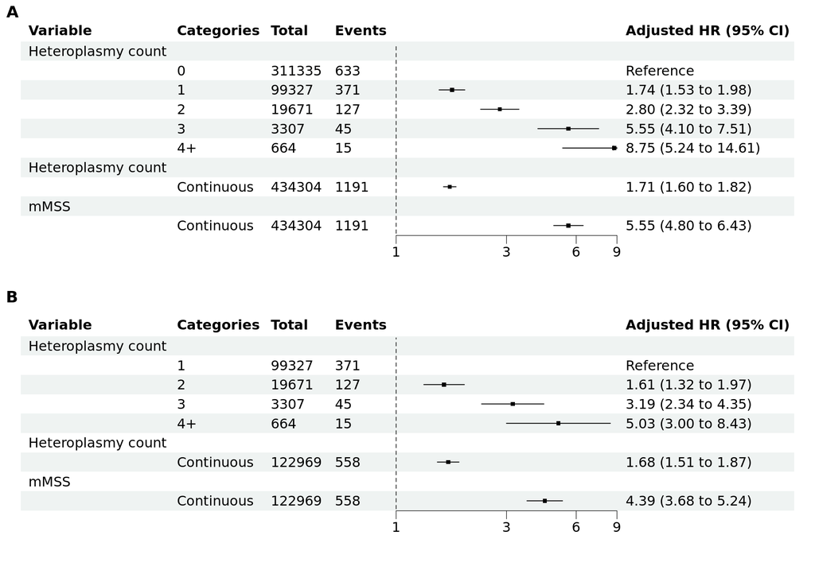

```r
combined <- ggpubr::ggarrange(p_hc_mss_all, p_hc_mss_het, labels = c("A", "B"), nrow = 2, ncol = 1, align = "v")
combined
```

```r
data <-
  data_all |>
  bind_rows(data_het) |>
  add_row(.before = 1) |>
  add_row(.before = 12) |>
  mutate(
    Panel = c("A", "", "", "", "", "", "", "", "", "", "", "B", "", "", "", "", "", "", "", "", "")
  ) |>
  dplyr::select(Panel, everything())

# Write the data to the sheets
openxlsx::writeData(wb, sheet = "Supplementary Figure 5", x = data)

# data |>
#   openxlsx::write.xlsx("ukb_mthet_chip_source_data_file.xlsx", sheetName = "Supplementary Figure 5")
```

# 7 Supplementary Figure 6 - Hazard ratios (95% confidence intervals) for the association between heteroplasmy and incident MN in individuals with CHIP.

## 7.1 Panel A

```r
# Heteroplasmy count in categories
hc_cat <-
  survival::coxph(surv_chip ~ count_het_cat + rms::rcs(age, 5) + sex + smk_ever + prev_cancer_yn, data = ukb_chip)
summary(hc_cat)
```

```
## Call:
## survival::coxph(formula = surv_chip ~ count_het_cat + rms::rcs(age,
##     5) + sex + smk_ever + prev_cancer_yn, data = ukb_chip)
##
##   n= 33597, number of events= 457
##
##                            coef exp(coef) se(coef)      z Pr(>|z|)
## count_het_cat1          0.60217   1.82607  0.10709  5.623 1.88e-08 ***
## count_het_cat2          1.01319   2.75438  0.14488  6.993 2.68e-12 ***
## count_het_cat3          1.82423   6.19800  0.20258  9.005  < 2e-16 ***
## count_het_cat4+         1.94017   6.95993  0.32505  5.969 2.39e-09 ***
## rms::rcs(age, 5)age     0.17960   1.19674  0.06164  2.914  0.00357 **
## rms::rcs(age, 5)age'   -0.11701   0.88958  0.12977 -0.902  0.36724
## rms::rcs(age, 5)age''  -0.01367   0.98642  0.77956 -0.018  0.98601
## rms::rcs(age, 5)age'''  2.35032  10.48894  2.32628  1.010  0.31233
## sexmen                  0.44399   1.55891  0.09567  4.641 3.47e-06 ***
## smk_everyes             0.13812   1.14812  0.10156  1.360  0.17380
## prev_cancer_yn         -0.16727   0.84597  0.16632 -1.006  0.31457
## ---
## Signif. codes:  0 '***' 0.001 '**' 0.01 '*' 0.05 '.' 0.1 ' ' 1
##
##                        exp(coef) exp(-coef) lower .95 upper .95
## count_het_cat1            1.8261    0.54762    1.4803     2.253
## count_het_cat2            2.7544    0.36306    2.0735     3.659
## count_het_cat3            6.1980    0.16134    4.1669     9.219
## count_het_cat4+           6.9599    0.14368    3.6806    13.161
## rms::rcs(age, 5)age       1.1967    0.83560    1.0606     1.350
## rms::rcs(age, 5)age'      0.8896    1.12413    0.6898     1.147
## rms::rcs(age, 5)age''     0.9864    1.01377    0.2140     4.546
## rms::rcs(age, 5)age'''   10.4889    0.09534    0.1098  1001.991
## sexmen                    1.5589    0.64147    1.2924     1.880
## smk_everyes               1.1481    0.87099    0.9409     1.401
## prev_cancer_yn            0.8460    1.18207    0.6106     1.172
##
## Concordance= 0.725  (se = 0.011 )
## Likelihood ratio test= 313  on 11 df,   p=<2e-16
## Wald test            = 294.2  on 11 df,   p=<2e-16
## Score (logrank) test = 375.9  on 11 df,   p=<2e-16
```

```r
hc_cat_table <-
  table(ukb_chip$count_het_cat, ukb_chip$cancer_dx_blood_mn, useNA = "ifany") |>
  unclass() |>
  as.data.frame() |>
  rename(
    control = `0`,
    case = `1`
  ) |>
  mutate(
    total = control + case
  )
hc_cat_table
```

```
##    control case total
## 0    21951  201 22152
## 1     8531  155  8686
## 2     2141   63  2204
## 3      399   28   427
## 4+     118   10   128
```

```r
coef_hc_cat <- summary(hc_cat)$coef[1:4, c(1:3, 5)]
coef_hc_cat
```

```
##                      coef exp(coef)  se(coef)     Pr(>|z|)
## count_het_cat1  0.6021675  1.826073 0.1070940 1.878936e-08
## count_het_cat2  1.0131938  2.754384 0.1448766 2.681195e-12
## count_het_cat3  1.8242273  6.198004 0.2025777 2.155226e-19
## count_het_cat4+ 1.9401693  6.959929 0.3250473 2.388827e-09
```

```r
# Heteroplasmy count as continuous
hc <-
  survival::coxph(surv_chip ~ count_het + rms::rcs(age, 5) + sex + smk_ever + prev_cancer_yn, data = ukb_chip)
summary(hc)
```

```
## Call:
## survival::coxph(formula = surv_chip ~ count_het + rms::rcs(age,
##     5) + sex + smk_ever + prev_cancer_yn, data = ukb_chip)
##
##   n= 33597, number of events= 457
##
##                            coef exp(coef) se(coef)      z Pr(>|z|)
## count_het               0.52649   1.69297  0.04536 11.607  < 2e-16 ***
## rms::rcs(age, 5)age     0.17948   1.19660  0.06162  2.913  0.00358 **
## rms::rcs(age, 5)age'   -0.11660   0.88994  0.12980 -0.898  0.36901
## rms::rcs(age, 5)age''  -0.01465   0.98545  0.77973 -0.019  0.98501
## rms::rcs(age, 5)age'''  2.34943  10.47958  2.32622  1.010  0.31251
## sexmen                  0.44223   1.55618  0.09567  4.623 3.79e-06 ***
## smk_everyes             0.14333   1.15410  0.10150  1.412  0.15792
## prev_cancer_yn         -0.16921   0.84433  0.16630 -1.017  0.30892
## ---
## Signif. codes:  0 '***' 0.001 '**' 0.01 '*' 0.05 '.' 0.1 ' ' 1
##
##                        exp(coef) exp(-coef) lower .95 upper .95
## count_het                 1.6930    0.59068    1.5490     1.850
## rms::rcs(age, 5)age       1.1966    0.83570    1.0605     1.350
## rms::rcs(age, 5)age'      0.8899    1.12367    0.6900     1.148
## rms::rcs(age, 5)age''     0.9855    1.01476    0.2138     4.543
## rms::rcs(age, 5)age'''   10.4796    0.09542    0.1097  1000.979
## sexmen                    1.5562    0.64260    1.2901     1.877
## smk_everyes               1.1541    0.86647    0.9459     1.408
## prev_cancer_yn            0.8443    1.18437    0.6095     1.170
##
## Concordance= 0.725  (se = 0.011 )
## Likelihood ratio test= 308.5  on 8 df,   p=<2e-16
## Wald test            = 293.4  on 8 df,   p=<2e-16
## Score (logrank) test = 341.8  on 8 df,   p=<2e-16
```

```r
hc_table <-
  table(ukb_chip$cancer_dx_blood_mn, useNA = "ifany") |>
  as.data.frame() |>
  spread(Var1, Freq) |>
  rename(
    control = `0`,
    case = `1`
  ) |>
  mutate(
    total = control + case
  )
hc_table
```

```
##   control case total
## 1   33140  457 33597
```

```r
coef_hc <- summary(hc)$coef[1, c(1:3, 5)]
coef_hc
```

```
##         coef    exp(coef)     se(coef)     Pr(>|z|)
## 5.264850e-01 1.692971e+00 4.535746e-02 3.776537e-31
```

```r
# mMSS
mss <-
  survival::coxph(surv_chip ~ mMSS + rms::rcs(age, 5) + sex + smk_ever + prev_cancer_yn, data = ukb_chip)
summary(mss)
```

```
## Call:
## survival::coxph(formula = surv_chip ~ mMSS + rms::rcs(age, 5) +
##     sex + smk_ever + prev_cancer_yn, data = ukb_chip)
##
##   n= 33597, number of events= 457
##
##                            coef exp(coef) se(coef)      z Pr(>|z|)
## mMSS                    1.43395   4.19525  0.10014 14.319  < 2e-16 ***
## rms::rcs(age, 5)age     0.17897   1.19599  0.06160  2.905  0.00367 **
## rms::rcs(age, 5)age'   -0.11882   0.88797  0.12980 -0.915  0.35997
## rms::rcs(age, 5)age''  -0.00368   0.99633  0.77942 -0.005  0.99623
## rms::rcs(age, 5)age'''  2.34079  10.38941  2.32555  1.007  0.31415
## sexmen                  0.43705   1.54813  0.09564  4.570 4.88e-06 ***
## smk_everyes             0.14835   1.15992  0.10145  1.462  0.14366
## prev_cancer_yn         -0.18827   0.82839  0.16637 -1.132  0.25777
## ---
## Signif. codes:  0 '***' 0.001 '**' 0.01 '*' 0.05 '.' 0.1 ' ' 1
##
##                        exp(coef) exp(-coef) lower .95 upper .95
## mMSS                      4.1953    0.23836    3.4476     5.105
## rms::rcs(age, 5)age       1.1960    0.83613    1.0600     1.349
## rms::rcs(age, 5)age'      0.8880    1.12617    0.6885     1.145
## rms::rcs(age, 5)age''     0.9963    1.00369    0.2162     4.590
## rms::rcs(age, 5)age'''   10.3894    0.09625    0.1089   991.066
## sexmen                    1.5481    0.64594    1.2835     1.867
## smk_everyes               1.1599    0.86213    0.9508     1.415
## prev_cancer_yn            0.8284    1.20716    0.5979     1.148
##
## Concordance= 0.723  (se = 0.012 )
## Likelihood ratio test= 333  on 8 df,   p=<2e-16
## Wald test            = 372.6  on 8 df,   p=<2e-16
## Score (logrank) test = 473.9  on 8 df,   p=<2e-16
```

```r
mss_table <-
  table(ukb_chip$cancer_dx_blood_mn, useNA = "ifany") |>
  as.data.frame() |>
  spread(Var1, Freq) |>
  rename(
    control = `0`,
    case = `1`
  ) |>
  mutate(
    total = control + case
  )
mss_table
```

```
##   control case total
## 1   33140  457 33597
```

```r
coef_mss <- summary(mss)$coef[1, c(1:3, 5)]
coef_mss
```

```
##         coef    exp(coef)     se(coef)     Pr(>|z|)
## 1.433953e+00 4.195252e+00 1.001404e-01 1.654704e-46
```

```r
coef <-
  rbind(coef_hc_cat, coef_hc, coef_mss) |>
  as_tibble() |>
  mutate(
    var = c("hc1", "hc2", "hc3", "hc4", "hc", "mss")
  ) |>
  rename(
    exp_coef = `exp(coef)`,
    se_coef = `se(coef)`
  ) |>
  dplyr::select(var, everything())
coef
```

```
## # A tibble: 6 x 5
##   var      coef exp_coef  se_coef `Pr(>|z|)`
##   <chr>   <dbl>    <dbl>    <dbl>      <dbl>
## 1 hc1   0.60217   1.8261 0.10709  1.8789e- 8
## 2 hc2   1.0132    2.7544 0.14488  2.6812e-12
## 3 hc3   1.8242    6.1980 0.20258  2.1552e-19
## 4 hc4   1.9402    6.9599 0.32505  2.3888e- 9
## 5 hc    0.52649   1.6930 0.045357 3.7765e-31
## 6 mss   1.4340    4.1953 0.10014  1.6547e-46
```

```r
# data transformation for forest plot
coef_all <- coef |>
  # add additional rows for categorical variables (1 for group name, 1 for reference) and 1 additional row for continuous variable (1 for group name)
  mutate(
    row = c(3:6, 8, 10)
  ) |>
  add_row(
    row = c(1:2, 7, 9)
  ) |>
  arrange(row) |>
  # add a column for group and category
  mutate(
    Variable =
      c("Heteroplasmy count", "", "", "", "", "", "Heteroplasmy count", "", "mMSS", ""),
    Categories =
      c("", "0", "1", "2", "3", "4+", "", "Continuous", "", "Continuous")
  )  %>%
  # tidy the estimates
  mutate(
    lci =
      ifelse(row == 1 | row == 2 | row == 7 | row == 9, 1, exp(coef - 1.96*se_coef)),
    uci =
      ifelse(row == 1 | row == 2 | row == 7 | row == 9, 1, exp(coef + 1.96*se_coef)),
    ` ` = paste(rep(" ", 25), collapse = " "),
    `Adjusted HR (95% CI)` = sprintf("%.2f (%.2f to %.2f)", exp_coef, lci, uci),
    `Adjusted HR (95% CI)` = case_when(
      row == 2 ~ "Reference",
      row == 1 | row == 7 | row == 9 ~ "",
      TRUE ~ `Adjusted HR (95% CI)`)
    ) |>
  dplyr::select(
    Variable, Categories, exp_coef, lci, uci, ` `, `Adjusted HR (95% CI)`, `Pr(>|z|)`, row
  )

coef_all
```

```
## # A tibble: 10 x 9
##    Variable      Categories exp_coef    lci     uci ` `   `Adjusted HR (95% CI)`
##    <chr>         <chr>         <dbl>  <dbl>   <dbl> <chr> <chr>
##  1 "Heteroplasm~ ""          NA      1       1      "   ~ ""
##  2 ""            "0"         NA      1       1      "   ~ "Reference"
##  3 ""            "1"          1.8261 1.4803  2.2526 "   ~ "1.83 (1.48 to 2.25)"
##  4 ""            "2"          2.7544 2.0735  3.6589 "   ~ "2.75 (2.07 to 3.66)"
##  5 ""            "3"          6.1980 4.1669  9.2191 "   ~ "6.20 (4.17 to 9.22)"
##  6 ""            "4+"         6.9599 3.6806 13.161  "   ~ "6.96 (3.68 to 13.16)"
##  7 "Heteroplasm~ ""          NA      1       1      "   ~ ""
##  8 ""            "Continuo~   1.6930 1.5490  1.8504 "   ~ "1.69 (1.55 to 1.85)"
##  9 "mMSS"        ""          NA      1       1      "   ~ ""
## 10 ""            "Continuo~   4.1953 3.4476  5.1050 "   ~ "4.20 (3.45 to 5.11)"
## # i 2 more variables: `Pr(>|z|)` <dbl>, row <dbl>
```

```r
table <-
  rbind(hc_cat_table, hc_table, mss_table) |>
  as_tibble() |>
  mutate(
    row = c(2:6, 8, 10)
  ) %>%
  add_row(
    row = c(1, 7, 9)
  ) %>%
  arrange(row)
table
```

```
## # A tibble: 10 x 4
##    control  case total   row
##      <int> <int> <int> <dbl>
##  1      NA    NA    NA     1
##  2   21951   201 22152     2
##  3    8531   155  8686     3
##  4    2141    63  2204     4
##  5     399    28   427     5
##  6     118    10   128     6
##  7      NA    NA    NA     7
##  8   33140   457 33597     8
##  9      NA    NA    NA     9
## 10   33140   457 33597    10
```

```r
data_all <-
  coef_all |>
  left_join(table, by = "row") |>
  mutate(
    total = as.character(total),
    total = case_when(
      row == 1 | row == 7 | row == 9 ~ "",
      TRUE ~ total
    ),
    case = as.character(case),
    case = case_when(
      row == 1 | row == 7 | row == 9 ~ "",
      TRUE ~ case
    )
  ) |>
  rename(
    Total = total,
    Events = case
  ) |>
  dplyr::select(
    Variable, Categories, Total, Events, ` `, `Adjusted HR (95% CI)`, exp_coef, lci, uci, `Pr(>|z|)`
  )
data_all
```

```
## # A tibble: 10 x 10
##    Variable Categories Total Events ` `   `Adjusted HR (95% CI)` exp_coef    lci
##    <chr>    <chr>      <chr> <chr>  <chr> <chr>                     <dbl>  <dbl>
##  1 "Hetero~ ""         ""    ""     "   ~ ""                      NA      1
##  2 ""       "0"        "221~ "201"  "   ~ "Reference"             NA      1
##  3 ""       "1"        "868~ "155"  "   ~ "1.83 (1.48 to 2.25)"    1.8261 1.4803
##  4 ""       "2"        "220~ "63"   "   ~ "2.75 (2.07 to 3.66)"    2.7544 2.0735
##  5 ""       "3"        "427" "28"   "   ~ "6.20 (4.17 to 9.22)"    6.1980 4.1669
##  6 ""       "4+"       "128" "10"   "   ~ "6.96 (3.68 to 13.16)"   6.9599 3.6806
##  7 "Hetero~ ""         ""    ""     "   ~ ""                      NA      1
##  8 ""       "Continuo~ "335~ "457"  "   ~ "1.69 (1.55 to 1.85)"    1.6930 1.5490
##  9 "mMSS"   ""         ""    ""     "   ~ ""                      NA      1
## 10 ""       "Continuo~ "335~ "457"  "   ~ "4.20 (3.45 to 5.11)"    4.1953 3.4476
## # i 2 more variables: uci <dbl>, `Pr(>|z|)` <dbl>
```

```r
p_hc_mss_all <-
  forestploter::forest(
  data_all[, c(1:6)],
  est = data_all$exp_coef,
  lower = data_all$lci,
  upper = data_all$uci,
  ci_column = 5,
  ref_line = 1,
  x_trans = "log",
  xlim = c(1, 9),
  ticks_at = c(1, 3, 6, 9)
  )
```

## 7.2 Panel B

```r
# Heteroplasmy count in categories
hc_cat <-
  survival::coxph(surv_chip_het ~ count_het_cat + rms::rcs(age, 5) + sex + smk_ever + prev_cancer_yn, data = ukb_chip_het)
summary(hc_cat)
```

```
## Call:
## survival::coxph(formula = surv_chip_het ~ count_het_cat + rms::rcs(age,
##     5) + sex + smk_ever + prev_cancer_yn, data = ukb_chip_het)
##
##   n= 11445, number of events= 256
##
##                            coef exp(coef) se(coef)      z Pr(>|z|)
## count_het_cat2          0.42187   1.52481  0.14964  2.819  0.00481 **
## count_het_cat3          1.25648   3.51304  0.20616  6.095 1.10e-09 ***
## count_het_cat4+         1.38018   3.97563  0.32757  4.213 2.52e-05 ***
## rms::rcs(age, 5)age     0.13882   1.14891  0.06623  2.096  0.03608 *
## rms::rcs(age, 5)age'   -0.07757   0.92536  0.13742 -0.564  0.57244
## rms::rcs(age, 5)age''  -0.18662   0.82976  0.89334 -0.209  0.83453
## rms::rcs(age, 5)age'''  2.91422  18.43442  3.09373  0.942  0.34620
## sexmen                  0.58864   1.80154  0.12966  4.540 5.63e-06 ***
## smk_everyes            -0.03021   0.97024  0.13335 -0.227  0.82077
## prev_cancer_yn         -0.11695   0.88963  0.21554 -0.543  0.58740
## ---
## Signif. codes:  0 '***' 0.001 '**' 0.01 '*' 0.05 '.' 0.1 ' ' 1
##
##                        exp(coef) exp(-coef) lower .95 upper .95
## count_het_cat2            1.5248    0.65582   1.13720     2.045
## count_het_cat3            3.5130    0.28465   2.34529     5.262
## count_het_cat4+           3.9756    0.25153   2.09206     7.555
## rms::rcs(age, 5)age       1.1489    0.87039   1.00905     1.308
## rms::rcs(age, 5)age'      0.9254    1.08066   0.70687     1.211
## rms::rcs(age, 5)age''     0.8298    1.20517   0.14406     4.779
## rms::rcs(age, 5)age'''   18.4344    0.05425   0.04288  7925.302
## sexmen                    1.8015    0.55508   1.39727     2.323
## smk_everyes               0.9702    1.03067   0.74708     1.260
## prev_cancer_yn            0.8896    1.12406   0.58310     1.357
##
## Concordance= 0.683  (se = 0.016 )
## Likelihood ratio test= 118.4  on 10 df,   p=<2e-16
## Wald test            = 114.8  on 10 df,   p=<2e-16
## Score (logrank) test = 133.1  on 10 df,   p=<2e-16
```

```r
hc_cat_table <-
  table(ukb_chip_het$count_het_cat, ukb_chip_het$cancer_dx_blood_mn, useNA = "ifany") |>
  unclass() |>
  as.data.frame() |>
  rename(
    control = `0`,
    case = `1`
  ) |>
  mutate(
    total = control + case
  )
hc_cat_table
```

```
##    control case total
## 1     8531  155  8686
## 2     2141   63  2204
## 3      399   28   427
## 4+     118   10   128
```

```r
coef_hc_cat <- summary(hc_cat)$coef[1:3, c(1:3, 5)]
coef_hc_cat
```

```
##                      coef exp(coef)  se(coef)     Pr(>|z|)
## count_het_cat2  0.4218705  1.524811 0.1496441 4.814975e-03
## count_het_cat3  1.2564808  3.513037 0.2061629 1.097099e-09
## count_het_cat4+ 1.3801827  3.975628 0.3275746 2.516235e-05
```

```r
# Heteroplasmy count as continuous
hc <-
  survival::coxph(surv_chip_het ~ count_het + rms::rcs(age, 5) + sex + smk_ever + prev_cancer_yn, data = ukb_chip_het)
summary(hc)
```

```
## Call:
## survival::coxph(formula = surv_chip_het ~ count_het + rms::rcs(age,
##     5) + sex + smk_ever + prev_cancer_yn, data = ukb_chip_het)
##
##   n= 11445, number of events= 256
##
##                            coef exp(coef) se(coef)      z Pr(>|z|)
## count_het               0.49527   1.64094  0.07275  6.808 9.92e-12 ***
## rms::rcs(age, 5)age     0.13793   1.14789  0.06614  2.085    0.037 *
## rms::rcs(age, 5)age'   -0.07522   0.92754  0.13744 -0.547    0.584
## rms::rcs(age, 5)age''  -0.20049   0.81833  0.89391 -0.224    0.823
## rms::rcs(age, 5)age'''  2.94987  19.10340  3.09523  0.953    0.341
## sexmen                  0.58513   1.79522  0.12963  4.514 6.37e-06 ***
## smk_everyes            -0.02057   0.97964  0.13322 -0.154    0.877
## prev_cancer_yn         -0.11965   0.88723  0.21550 -0.555    0.579
## ---
## Signif. codes:  0 '***' 0.001 '**' 0.01 '*' 0.05 '.' 0.1 ' ' 1
##
##                        exp(coef) exp(-coef) lower .95 upper .95
## count_het                 1.6409    0.60941    1.4229     1.892
## rms::rcs(age, 5)age       1.1479    0.87116    1.0083     1.307
## rms::rcs(age, 5)age'      0.9275    1.07812    0.7085     1.214
## rms::rcs(age, 5)age''     0.8183    1.22200    0.1419     4.719
## rms::rcs(age, 5)age'''   19.1034    0.05235    0.0443  8237.041
## sexmen                    1.7952    0.55703    1.3924     2.315
## smk_everyes               0.9796    1.02078    0.7545     1.272
## prev_cancer_yn            0.8872    1.12711    0.5816     1.354
##
## Concordance= 0.683  (se = 0.016 )
## Likelihood ratio test= 114.3  on 8 df,   p=<2e-16
## Wald test            = 109.6  on 8 df,   p=<2e-16
## Score (logrank) test = 121.5  on 8 df,   p=<2e-16
```

```r
hc_table <-
  table(ukb_chip_het$cancer_dx_blood_mn, useNA = "ifany") |>
  as.data.frame() |>
  spread(Var1, Freq) |>
  rename(
    control = `0`,
    case = `1`
  ) |>
  mutate(
    total = control + case
  )
hc_table
```

```
##   control case total
## 1   11189  256 11445
```

```r
coef_hc <- summary(hc)$coef[1, c(1:3, 5)]
coef_hc
```

```
##         coef    exp(coef)     se(coef)     Pr(>|z|)
## 4.952667e-01 1.640936e+00 7.275072e-02 9.915567e-12
```

```r
# mMSS
mss <-
  survival::coxph(surv_chip_het ~ mMSS + rms::rcs(age, 5) + sex + smk_ever + prev_cancer_yn, data = ukb_chip_het)
summary(mss)
```

```
## Call:
## survival::coxph(formula = surv_chip_het ~ mMSS + rms::rcs(age,
##     5) + sex + smk_ever + prev_cancer_yn, data = ukb_chip_het)
##
##   n= 11445, number of events= 256
##
##                            coef exp(coef) se(coef)      z Pr(>|z|)
## mMSS                    1.22686   3.41052  0.12124 10.119  < 2e-16 ***
## rms::rcs(age, 5)age     0.13008   1.13892  0.06593  1.973   0.0485 *
## rms::rcs(age, 5)age'   -0.07209   0.93045  0.13732 -0.525   0.5996
## rms::rcs(age, 5)age''  -0.22136   0.80143  0.89338 -0.248   0.8043
## rms::rcs(age, 5)age'''  3.04150  20.93671  3.09227  0.984   0.3253
## sexmen                  0.56783   1.76444  0.12958  4.382 1.18e-05 ***
## smk_everyes            -0.01649   0.98365  0.13308 -0.124   0.9014
## prev_cancer_yn         -0.15907   0.85293  0.21560 -0.738   0.4606
## ---
## Signif. codes:  0 '***' 0.001 '**' 0.01 '*' 0.05 '.' 0.1 ' ' 1
##
##                        exp(coef) exp(-coef) lower .95 upper .95
## mMSS                      3.4105    0.29321   2.68917     4.325
## rms::rcs(age, 5)age       1.1389    0.87803   1.00086     1.296
## rms::rcs(age, 5)age'      0.9305    1.07475   0.71089     1.218
## rms::rcs(age, 5)age''     0.8014    1.24777   0.13913     4.616
## rms::rcs(age, 5)age'''   20.9367    0.04776   0.04884  8975.369
## sexmen                    1.7644    0.56675   1.36870     2.275
## smk_everyes               0.9836    1.01662   0.75782     1.277
## prev_cancer_yn            0.8529    1.17243   0.55898     1.301
##
## Concordance= 0.7  (se = 0.016 )
## Likelihood ratio test= 154.8  on 8 df,   p=<2e-16
## Wald test            = 167.8  on 8 df,   p=<2e-16
## Score (logrank) test = 189.7  on 8 df,   p=<2e-16
```

```r
mss_table <-
  table(ukb_chip_het$cancer_dx_blood_mn, useNA = "ifany") |>
  as.data.frame() |>
  spread(Var1, Freq) |>
  rename(
    control = `0`,
    case = `1`
  ) |>
  mutate(
    total = control + case
  )
mss_table
```

```
##   control case total
## 1   11189  256 11445
```

```r
coef_mss <- summary(mss)$coef[1, c(1:3, 5)]
coef_mss
```

```
##         coef    exp(coef)     se(coef)     Pr(>|z|)
## 1.226865e+00 3.410520e+00 1.212425e-01 4.545736e-24
```

```r
coef <-
  rbind(coef_hc_cat, coef_hc, coef_mss) |>
  as_tibble() |>
  mutate(
    var = c("hc2", "hc3", "hc4", "hc", "mss")
  ) |>
  rename(
    exp_coef = `exp(coef)`,
    se_coef = `se(coef)`
  ) |>
  dplyr::select(var, everything())
coef
```

```
## # A tibble: 5 x 5
##   var      coef exp_coef  se_coef `Pr(>|z|)`
##   <chr>   <dbl>    <dbl>    <dbl>      <dbl>
## 1 hc2   0.42187   1.5248 0.14964  4.8150e- 3
## 2 hc3   1.2565    3.5130 0.20616  1.0971e- 9
## 3 hc4   1.3802    3.9756 0.32757  2.5162e- 5
## 4 hc    0.49527   1.6409 0.072751 9.9156e-12
## 5 mss   1.2269    3.4105 0.12124  4.5457e-24
```

```r
# data transformation for forest plot
coef_all <- coef |>
  # add additional rows for categorical variables (1 for group name, 1 for reference) and 1 additional row for continuous variable (1 for group name)
  mutate(
    row = c(3:5, 7, 9)
  ) |>
  add_row(
    row = c(1:2, 6, 8)
  ) |>
  arrange(row) |>
  # add a column for group and category
  mutate(
    Variable =
      c("Heteroplasmy count", "", "", "", "", "Heteroplasmy count", "", "mMSS", ""),
    Categories =
      c("", "1", "2", "3", "4+", "", "Continuous", "", "Continuous")
  )  %>%
  # tidy the estimates
  mutate(
    lci =
      ifelse(row == 1 | row == 2 | row == 6 | row == 8, 1, exp(coef - 1.96*se_coef)),
    uci =
      ifelse(row == 1 | row == 2 | row == 6 | row == 8, 1, exp(coef + 1.96*se_coef)),
    ` ` = paste(rep(" ", 25), collapse = " "),
    `Adjusted HR (95% CI)` = sprintf("%.2f (%.2f to %.2f)", exp_coef, lci, uci),
    `Adjusted HR (95% CI)` = case_when(
      row == 2 ~ "Reference",
      row == 1 | row == 6 | row == 8 ~ "",
      TRUE ~ `Adjusted HR (95% CI)`)
    ) |>
  dplyr::select(
    Variable, Categories, exp_coef, lci, uci, ` `, `Adjusted HR (95% CI)`, `Pr(>|z|)`, row
  )

coef_all
```

```
## # A tibble: 9 x 9
##   Variable        Categories exp_coef    lci    uci ` `   `Adjusted HR (95% CI)`
##   <chr>           <chr>         <dbl>  <dbl>  <dbl> <chr> <chr>
## 1 "Heteroplasmy ~ ""          NA      1      1      "   ~ ""
## 2 ""              "1"         NA      1      1      "   ~ "Reference"
## 3 ""              "2"          1.5248 1.1372 2.0445 "   ~ "1.52 (1.14 to 2.04)"
## 4 ""              "3"          3.5130 2.3453 5.2623 "   ~ "3.51 (2.35 to 5.26)"
## 5 ""              "4+"         3.9756 2.0920 7.5551 "   ~ "3.98 (2.09 to 7.56)"
## 6 "Heteroplasmy ~ ""          NA      1      1      "   ~ ""
## 7 ""              "Continuo~   1.6409 1.4229 1.8924 "   ~ "1.64 (1.42 to 1.89)"
## 8 "mMSS"          ""          NA      1      1      "   ~ ""
## 9 ""              "Continuo~   3.4105 2.6892 4.3254 "   ~ "3.41 (2.69 to 4.33)"
## # i 2 more variables: `Pr(>|z|)` <dbl>, row <dbl>
```

```r
table <-
  rbind(hc_cat_table, hc_table, mss_table) |>
  as_tibble() |>
  mutate(
    row = c(2:5, 7, 9)
  ) %>%
  add_row(
    row = c(1, 6, 8)
  ) %>%
  arrange(row)
table
```

```
## # A tibble: 9 x 4
##   control  case total   row
##     <int> <int> <int> <dbl>
## 1      NA    NA    NA     1
## 2    8531   155  8686     2
## 3    2141    63  2204     3
## 4     399    28   427     4
## 5     118    10   128     5
## 6      NA    NA    NA     6
## 7   11189   256 11445     7
## 8      NA    NA    NA     8
## 9   11189   256 11445     9
```

```r
data_het <-
  coef_all |>
  left_join(table, by = "row") |>
  mutate(
    total = as.character(total),
    total = case_when(
      row == 1 | row == 6 | row == 8 ~ "",
      TRUE ~ total
    ),
    case = as.character(case),
    case = case_when(
      row == 1 | row == 6 | row == 8 ~ "",
      TRUE ~ case
    )
  ) |>
  rename(
    Total = total,
    Events = case
  ) |>
  dplyr::select(
    Variable, Categories, Total, Events, ` `, `Adjusted HR (95% CI)`, exp_coef, lci, uci, `Pr(>|z|)`
  )
data_het
```

```
## # A tibble: 9 x 10
##   Variable  Categories Total Events ` `   `Adjusted HR (95% CI)` exp_coef    lci
##   <chr>     <chr>      <chr> <chr>  <chr> <chr>                     <dbl>  <dbl>
## 1 "Heterop~ ""         ""    ""     "   ~ ""                      NA      1
## 2 ""        "1"        "868~ "155"  "   ~ "Reference"             NA      1
## 3 ""        "2"        "220~ "63"   "   ~ "1.52 (1.14 to 2.04)"    1.5248 1.1372
## 4 ""        "3"        "427" "28"   "   ~ "3.51 (2.35 to 5.26)"    3.5130 2.3453
## 5 ""        "4+"       "128" "10"   "   ~ "3.98 (2.09 to 7.56)"    3.9756 2.0920
## 6 "Heterop~ ""         ""    ""     "   ~ ""                      NA      1
## 7 ""        "Continuo~ "114~ "256"  "   ~ "1.64 (1.42 to 1.89)"    1.6409 1.4229
## 8 "mMSS"    ""         ""    ""     "   ~ ""                      NA      1
## 9 ""        "Continuo~ "114~ "256"  "   ~ "3.41 (2.69 to 4.33)"    3.4105 2.6892
## # i 2 more variables: uci <dbl>, `Pr(>|z|)` <dbl>
```

```r
p_hc_mss_het <-
  forestploter::forest(
  data_het[, c(1:6)],
  est = data_het$exp_coef,
  lower = data_het$lci,
  upper = data_het$uci,
  ci_column = 5,
  ref_line = 1,
  x_trans = "log",
  xlim = c(1, 9),
  ticks_at = c(1, 3, 6, 9)
  )
```

## 7.3 Combined

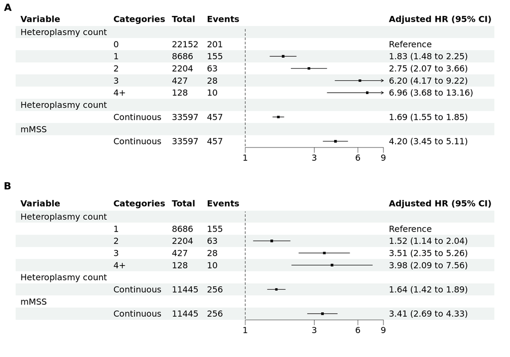

```r
combined <- ggpubr::ggarrange(p_hc_mss_all, p_hc_mss_het, labels = c("A", "B"), nrow = 2, ncol = 1, align = "v")
combined
```

```r
data <-
  data_all |>
  bind_rows(data_het) |>
  add_row(.before = 1) |>
  add_row(.before = 12) |>
  mutate(
    Panel = c("A", "", "", "", "", "", "", "", "", "", "", "B", "", "", "", "", "", "", "", "", "")
  ) |>
  dplyr::select(Panel, everything())

# Write the data to the sheets
openxlsx::writeData(wb, sheet = "Supplementary Figure 6", x = data)

# data |>
#   openxlsx::write.xlsx("ukb_mthet_chip_source_data_file.xlsx", sheetName = "Supplementary Figure 6", append = TRUE)
```

# 8 Supplementary Figure 7 - Hazard ratios (95% confidence intervals) for the association between heteroplasmy and incident MN in individuals without CHIP.

## 8.1 Panel A

```r
# Heteroplasmy count in categories
hc_cat <-
  survival::coxph(surv_nochip ~ count_het_cat + rms::rcs(age, 5) + sex + smk_ever + prev_cancer_yn, data = ukb_nochip)
summary(hc_cat)
```

```
## Call:
## survival::coxph(formula = surv_nochip ~ count_het_cat + rms::rcs(age,
##     5) + sex + smk_ever + prev_cancer_yn, data = ukb_nochip)
##
##   n= 400707, number of events= 734
##
##                            coef exp(coef) se(coef)      z Pr(>|z|)
## count_het_cat1          0.42793   1.53408  0.08339  5.132 2.87e-07 ***
## count_het_cat2          0.80112   2.22803  0.13412  5.973 2.33e-09 ***
## count_het_cat3          1.22110   3.39093  0.24753  4.933 8.09e-07 ***
## count_het_cat4+         1.65767   5.24705  0.45002  3.684  0.00023 ***
## rms::rcs(age, 5)age     0.04725   1.04838  0.03917  1.206  0.22777
## rms::rcs(age, 5)age'    0.05755   1.05923  0.13639  0.422  0.67308
## rms::rcs(age, 5)age''  -0.33038   0.71865  0.60933 -0.542  0.58768
## rms::rcs(age, 5)age'''  0.82982   2.29291  1.05112  0.789  0.42984
## sexmen                  0.34589   1.41324  0.07477  4.626 3.73e-06 ***
## smk_everyes             0.11244   1.11900  0.07770  1.447  0.14785
## prev_cancer_yn          0.30654   1.35872  0.12036  2.547  0.01087 *
## ---
## Signif. codes:  0 '***' 0.001 '**' 0.01 '*' 0.05 '.' 0.1 ' ' 1
##
##                        exp(coef) exp(-coef) lower .95 upper .95
## count_het_cat1            1.5341     0.6519    1.3028     1.806
## count_het_cat2            2.2280     0.4488    1.7130     2.898
## count_het_cat3            3.3909     0.2949    2.0875     5.508
## count_het_cat4+           5.2470     0.1906    2.1720    12.676
## rms::rcs(age, 5)age       1.0484     0.9539    0.9709     1.132
## rms::rcs(age, 5)age'      1.0592     0.9441    0.8108     1.384
## rms::rcs(age, 5)age''     0.7187     1.3915    0.2177     2.372
## rms::rcs(age, 5)age'''    2.2929     0.4361    0.2922    17.993
## sexmen                    1.4132     0.7076    1.2206     1.636
## smk_everyes               1.1190     0.8937    0.9609     1.303
## prev_cancer_yn            1.3587     0.7360    1.0732     1.720
##
## Concordance= 0.677  (se = 0.01 )
## Likelihood ratio test= 305.5  on 11 df,   p=<2e-16
## Wald test            = 311.2  on 11 df,   p=<2e-16
## Score (logrank) test = 347.4  on 11 df,   p=<2e-16
```

```r
hc_cat_table <-
  table(ukb_nochip$count_het_cat, ukb_nochip$cancer_dx_blood_mn, useNA = "ifany") |>
  unclass() |>
  as.data.frame() |>
  rename(
    control = `0`,
    case = `1`
  ) |>
  mutate(
    total = control + case
  )
hc_cat_table
```

```
##    control case  total
## 0   288751  432 289183
## 1    90425  216  90641
## 2    17403   64  17467
## 3     2863   17   2880
## 4+     531    5    536
```

```r
coef_hc_cat <- summary(hc_cat)$coef[1:4, c(1:3, 5)]
coef_hc_cat
```

```
##                      coef exp(coef)   se(coef)     Pr(>|z|)
## count_het_cat1  0.4279296  1.534078 0.08339102 2.872858e-07
## count_het_cat2  0.8011162  2.228026 0.13412202 2.328726e-09
## count_het_cat3  1.2211034  3.390927 0.24753177 8.092725e-07
## count_het_cat4+ 1.6576660  5.247050 0.45002348 2.300443e-04
```

```r
# Heteroplasmy count as continuous
hc <-
  survival::coxph(surv_nochip ~ count_het + rms::rcs(age, 5) + sex + smk_ever + prev_cancer_yn, data = ukb_nochip)
summary(hc)
```

```
## Call:
## survival::coxph(formula = surv_nochip ~ count_het + rms::rcs(age,
##     5) + sex + smk_ever + prev_cancer_yn, data = ukb_nochip)
##
##   n= 400707, number of events= 734
##
##                            coef exp(coef) se(coef)      z Pr(>|z|)
## count_het               0.40417   1.49805  0.04557  8.870  < 2e-16 ***
## rms::rcs(age, 5)age     0.04725   1.04838  0.03917  1.206   0.2277
## rms::rcs(age, 5)age'    0.05752   1.05920  0.13638  0.422   0.6732
## rms::rcs(age, 5)age''  -0.33010   0.71885  0.60931 -0.542   0.5880
## rms::rcs(age, 5)age'''  0.82936   2.29186  1.05109  0.789   0.4301
## sexmen                  0.34573   1.41302  0.07477  4.624 3.77e-06 ***
## smk_everyes             0.11252   1.11910  0.07769  1.448   0.1475
## prev_cancer_yn          0.30676   1.35901  0.12036  2.549   0.0108 *
## ---
## Signif. codes:  0 '***' 0.001 '**' 0.01 '*' 0.05 '.' 0.1 ' ' 1
##
##                        exp(coef) exp(-coef) lower .95 upper .95
## count_het                 1.4981     0.6675    1.3701     1.638
## rms::rcs(age, 5)age       1.0484     0.9539    0.9709     1.132
## rms::rcs(age, 5)age'      1.0592     0.9441    0.8108     1.384
## rms::rcs(age, 5)age''     0.7189     1.3911    0.2178     2.373
## rms::rcs(age, 5)age'''    2.2919     0.4363    0.2921    17.984
## sexmen                    1.4130     0.7077    1.2204     1.636
## smk_everyes               1.1191     0.8936    0.9610     1.303
## prev_cancer_yn            1.3590     0.7358    1.0734     1.721
##
## Concordance= 0.677  (se = 0.01 )
## Likelihood ratio test= 304.6  on 8 df,   p=<2e-16
## Wald test            = 311.4  on 8 df,   p=<2e-16
## Score (logrank) test = 339.2  on 8 df,   p=<2e-16
```

```r
hc_table <-
  table(ukb_nochip$cancer_dx_blood_mn, useNA = "ifany") |>
  as.data.frame() |>
  spread(Var1, Freq) |>
  rename(
    control = `0`,
    case = `1`
  ) |>
  mutate(
    total = control + case
  )
hc_table
```

```
##   control case  total
## 1  399973  734 400707
```

```r
coef_hc <- summary(hc)$coef[1, c(1:3, 5)]
coef_hc
```

```
##         coef    exp(coef)     se(coef)     Pr(>|z|)
## 4.041671e-01 1.498054e+00 4.556783e-02 7.342863e-19
```

```r
# mMSS
mss <-
  survival::coxph(surv_nochip ~ mMSS + rms::rcs(age, 5) + sex + smk_ever + prev_cancer_yn, data = ukb_nochip)
summary(mss)
```

```
## Call:
## survival::coxph(formula = surv_nochip ~ mMSS + rms::rcs(age,
##     5) + sex + smk_ever + prev_cancer_yn, data = ukb_nochip)
##
##   n= 400707, number of events= 734
##
##                            coef exp(coef) se(coef)      z Pr(>|z|)
## mMSS                    1.45451   4.28238  0.12081 12.040   <2e-16 ***
## rms::rcs(age, 5)age     0.04731   1.04844  0.03916  1.208   0.2271
## rms::rcs(age, 5)age'    0.05566   1.05724  0.13636  0.408   0.6831
## rms::rcs(age, 5)age''  -0.32527   0.72233  0.60922 -0.534   0.5934
## rms::rcs(age, 5)age'''  0.81402   2.25696  1.05091  0.775   0.4386
## sexmen                  0.34151   1.40707  0.07481  4.565    5e-06 ***
## smk_everyes             0.10622   1.11207  0.07775  1.366   0.1719
## prev_cancer_yn          0.30134   1.35167  0.12035  2.504   0.0123 *
## ---
## Signif. codes:  0 '***' 0.001 '**' 0.01 '*' 0.05 '.' 0.1 ' ' 1
##
##                        exp(coef) exp(-coef) lower .95 upper .95
## mMSS                      4.2824     0.2335    3.3795     5.426
## rms::rcs(age, 5)age       1.0484     0.9538    0.9710     1.132
## rms::rcs(age, 5)age'      1.0572     0.9459    0.8093     1.381
## rms::rcs(age, 5)age''     0.7223     1.3844    0.2189     2.384
## rms::rcs(age, 5)age'''    2.2570     0.4431    0.2877    17.703
## sexmen                    1.4071     0.7107    1.2152     1.629
## smk_everyes               1.1121     0.8992    0.9549     1.295
## prev_cancer_yn            1.3517     0.7398    1.0677     1.711
##
## Concordance= 0.684  (se = 0.01 )
## Likelihood ratio test= 332.1  on 8 df,   p=<2e-16
## Wald test            = 395.8  on 8 df,   p=<2e-16
## Score (logrank) test = 449  on 8 df,   p=<2e-16
```

```r
mss_table <-
  table(ukb_nochip$cancer_dx_blood_mn, useNA = "ifany") |>
  as.data.frame() |>
  spread(Var1, Freq) |>
  rename(
    control = `0`,
    case = `1`
  ) |>
  mutate(
    total = control + case
  )
mss_table
```

```
##   control case  total
## 1  399973  734 400707
```

```r
coef_mss <- summary(mss)$coef[1, c(1:3, 5)]
coef_mss
```

```
##         coef    exp(coef)     se(coef)     Pr(>|z|)
## 1.454510e+00 4.282383e+00 1.208062e-01 2.188919e-33
```

```r
coef <-
  rbind(coef_hc_cat, coef_hc, coef_mss) |>
  as_tibble() |>
  mutate(
    var = c("hc1", "hc2", "hc3", "hc4", "hc", "mss")
  ) |>
  rename(
    exp_coef = `exp(coef)`,
    se_coef = `se(coef)`
  ) |>
  dplyr::select(var, everything())
coef
```

```
## # A tibble: 6 x 5
##   var      coef exp_coef  se_coef `Pr(>|z|)`
##   <chr>   <dbl>    <dbl>    <dbl>      <dbl>
## 1 hc1   0.42793   1.5341 0.083391 2.8729e- 7
## 2 hc2   0.80112   2.2280 0.13412  2.3287e- 9
## 3 hc3   1.2211    3.3909 0.24753  8.0927e- 7
## 4 hc4   1.6577    5.2470 0.45002  2.3004e- 4
## 5 hc    0.40417   1.4981 0.045568 7.3429e-19
## 6 mss   1.4545    4.2824 0.12081  2.1889e-33
```

```r
# data transformation for forest plot
coef_all <- coef |>
  # add additional rows for categorical variables (1 for group name, 1 for reference) and 1 additional row for continuous variable (1 for group name)
  mutate(
    row = c(3:6, 8, 10)
  ) |>
  add_row(
    row = c(1:2, 7, 9)
  ) |>
  arrange(row) |>
  # add a column for group and category
  mutate(
    Variable =
      c("Heteroplasmy count", "", "", "", "", "", "Heteroplasmy count", "", "mMSS", ""),
    Categories =
      c("", "0", "1", "2", "3", "4+", "", "Continuous", "", "Continuous")
  )  %>%
  # tidy the estimates
  mutate(
    lci =
      ifelse(row == 1 | row == 2 | row == 7 | row == 9, 1, exp(coef - 1.96*se_coef)),
    uci =
      ifelse(row == 1 | row == 2 | row == 7 | row == 9, 1, exp(coef + 1.96*se_coef)),
    ` ` = paste(rep(" ", 25), collapse = " "),
    `Adjusted HR (95% CI)` = sprintf("%.2f (%.2f to %.2f)", exp_coef, lci, uci),
    `Adjusted HR (95% CI)` = case_when(
      row == 2 ~ "Reference",
      row == 1 | row == 7 | row == 9 ~ "",
      TRUE ~ `Adjusted HR (95% CI)`)
    ) |>
  dplyr::select(
    Variable, Categories, exp_coef, lci, uci, ` `, `Adjusted HR (95% CI)`, `Pr(>|z|)`, row
  )

coef_all
```

```
## # A tibble: 10 x 9
##    Variable      Categories exp_coef    lci     uci ` `   `Adjusted HR (95% CI)`
##    <chr>         <chr>         <dbl>  <dbl>   <dbl> <chr> <chr>
##  1 "Heteroplasm~ ""          NA      1       1      "   ~ ""
##  2 ""            "0"         NA      1       1      "   ~ "Reference"
##  3 ""            "1"          1.5341 1.3028  1.8065 "   ~ "1.53 (1.30 to 1.81)"
##  4 ""            "2"          2.2280 1.7130  2.8979 "   ~ "2.23 (1.71 to 2.90)"
##  5 ""            "3"          3.3909 2.0874  5.5084 "   ~ "3.39 (2.09 to 5.51)"
##  6 ""            "4+"         5.2470 2.1719 12.676  "   ~ "5.25 (2.17 to 12.68)"
##  7 "Heteroplasm~ ""          NA      1       1      "   ~ ""
##  8 ""            "Continuo~   1.4981 1.3701  1.6380 "   ~ "1.50 (1.37 to 1.64)"
##  9 "mMSS"        ""          NA      1       1      "   ~ ""
## 10 ""            "Continuo~   4.2824 3.3795  5.4265 "   ~ "4.28 (3.38 to 5.43)"
## # i 2 more variables: `Pr(>|z|)` <dbl>, row <dbl>
```

```r
table <-
  rbind(hc_cat_table, hc_table, mss_table) |>
  as_tibble() |>
  mutate(
    row = c(2:6, 8, 10)
  ) %>%
  add_row(
    row = c(1, 7, 9)
  ) %>%
  arrange(row)
table
```

```
## # A tibble: 10 x 4
##    control  case  total   row
##      <int> <int>  <int> <dbl>
##  1      NA    NA     NA     1
##  2  288751   432 289183     2
##  3   90425   216  90641     3
##  4   17403    64  17467     4
##  5    2863    17   2880     5
##  6     531     5    536     6
##  7      NA    NA     NA     7
##  8  399973   734 400707     8
##  9      NA    NA     NA     9
## 10  399973   734 400707    10
```

```r
data_all <-
  coef_all |>
  left_join(table, by = "row") |>
  mutate(
    total = as.character(total),
    total = case_when(
      row == 1 | row == 7 | row == 9 ~ "",
      TRUE ~ total
    ),
    case = as.character(case),
    case = case_when(
      row == 1 | row == 7 | row == 9 ~ "",
      TRUE ~ case
    )
  ) |>
  rename(
    Total = total,
    Events = case
  ) |>
  dplyr::select(
    Variable, Categories, Total, Events, ` `, `Adjusted HR (95% CI)`, exp_coef, lci, uci, `Pr(>|z|)`
  )
data_all
```

```
## # A tibble: 10 x 10
##    Variable Categories Total Events ` `   `Adjusted HR (95% CI)` exp_coef    lci
##    <chr>    <chr>      <chr> <chr>  <chr> <chr>                     <dbl>  <dbl>
##  1 "Hetero~ ""         ""    ""     "   ~ ""                      NA      1
##  2 ""       "0"        "289~ "432"  "   ~ "Reference"             NA      1
##  3 ""       "1"        "906~ "216"  "   ~ "1.53 (1.30 to 1.81)"    1.5341 1.3028
##  4 ""       "2"        "174~ "64"   "   ~ "2.23 (1.71 to 2.90)"    2.2280 1.7130
##  5 ""       "3"        "288~ "17"   "   ~ "3.39 (2.09 to 5.51)"    3.3909 2.0874
##  6 ""       "4+"       "536" "5"    "   ~ "5.25 (2.17 to 12.68)"   5.2470 2.1719
##  7 "Hetero~ ""         ""    ""     "   ~ ""                      NA      1
##  8 ""       "Continuo~ "400~ "734"  "   ~ "1.50 (1.37 to 1.64)"    1.4981 1.3701
##  9 "mMSS"   ""         ""    ""     "   ~ ""                      NA      1
## 10 ""       "Continuo~ "400~ "734"  "   ~ "4.28 (3.38 to 5.43)"    4.2824 3.3795
## # i 2 more variables: uci <dbl>, `Pr(>|z|)` <dbl>
```

```r
p_hc_mss_all <-
  forestploter::forest(
  data_all[, c(1:6)],
  est = data_all$exp_coef,
  lower = data_all$lci,
  upper = data_all$uci,
  ci_column = 5,
  ref_line = 1,
  x_trans = "log",
  xlim = c(1, 9),
  ticks_at = c(1, 3, 6, 9)
  )
```

## 8.2 Panel B

```r
# Heteroplasmy count in categories
hc_cat <-
  survival::coxph(surv_nochip_het ~ count_het_cat + rms::rcs(age, 5) + sex + smk_ever + prev_cancer_yn, data = ukb_nochip_het)
summary(hc_cat)
```

```
## Call:
## survival::coxph(formula = surv_nochip_het ~ count_het_cat + rms::rcs(age,
##     5) + sex + smk_ever + prev_cancer_yn, data = ukb_nochip_het)
##
##   n= 111524, number of events= 302
##
##                            coef exp(coef) se(coef)      z Pr(>|z|)
## count_het_cat2          0.37194   1.45055  0.14246  2.611  0.00903 **
## count_het_cat3          0.78948   2.20226  0.25225  3.130  0.00175 **
## count_het_cat4+         1.22683   3.41040  0.45271  2.710  0.00673 **
## rms::rcs(age, 5)age    -0.02964   0.97079  0.06008 -0.493  0.62173
## rms::rcs(age, 5)age'    0.31317   1.36776  0.20022  1.564  0.11779
## rms::rcs(age, 5)age''  -1.18759   0.30495  0.78964 -1.504  0.13259
## rms::rcs(age, 5)age'''  2.10844   8.23535  1.50258  1.403  0.16055
## sexmen                  0.25642   1.29230  0.11633  2.204  0.02750 *
## smk_everyes             0.13390   1.14328  0.12214  1.096  0.27293
## prev_cancer_yn          0.28090   1.32432  0.18393  1.527  0.12671
## ---
## Signif. codes:  0 '***' 0.001 '**' 0.01 '*' 0.05 '.' 0.1 ' ' 1
##
##                        exp(coef) exp(-coef) lower .95 upper .95
## count_het_cat2            1.4506     0.6894   1.09717     1.918
## count_het_cat3            2.2023     0.4541   1.34325     3.611
## count_het_cat4+           3.4104     0.2932   1.40429     8.282
## rms::rcs(age, 5)age       0.9708     1.0301   0.86295     1.092
## rms::rcs(age, 5)age'      1.3678     0.7311   0.92380     2.025
## rms::rcs(age, 5)age''     0.3050     3.2792   0.06488     1.433
## rms::rcs(age, 5)age'''    8.2353     0.1214   0.43319   156.560
## sexmen                    1.2923     0.7738   1.02883     1.623
## smk_everyes               1.1433     0.8747   0.89989     1.453
## prev_cancer_yn            1.3243     0.7551   0.92349     1.899
##
## Concordance= 0.676  (se = 0.015 )
## Likelihood ratio test= 117.2  on 10 df,   p=<2e-16
## Wald test            = 114.8  on 10 df,   p=<2e-16
## Score (logrank) test = 128.5  on 10 df,   p=<2e-16
```

```r
hc_cat_table <-
  table(ukb_nochip_het$count_het_cat, ukb_nochip_het$cancer_dx_blood_mn, useNA = "ifany") |>
  unclass() |>
  as.data.frame() |>
  rename(
    control = `0`,
    case = `1`
  ) |>
  mutate(
    total = control + case
  )
hc_cat_table
```

```
##    control case total
## 1    90425  216 90641
## 2    17403   64 17467
## 3     2863   17  2880
## 4+     531    5   536
```

```r
coef_hc_cat <- summary(hc_cat)$coef[1:3, c(1:3, 5)]
coef_hc_cat
```

```
##                      coef exp(coef)  se(coef)    Pr(>|z|)
## count_het_cat2  0.3719431  1.450550 0.1424570 0.009030026
## count_het_cat3  0.7894827  2.202257 0.2522464 0.001749209
## count_het_cat4+ 1.2268282  3.410395 0.4527098 0.006729011
```

```r
# Heteroplasmy count as continuous
hc <-
  survival::coxph(surv_nochip_het ~ count_het + rms::rcs(age, 5) + sex + smk_ever + prev_cancer_yn, data = ukb_nochip_het)
summary(hc)
```

```
## Call:
## survival::coxph(formula = surv_nochip_het ~ count_het + rms::rcs(age,
##     5) + sex + smk_ever + prev_cancer_yn, data = ukb_nochip_het)
##
##   n= 111524, number of events= 302
##
##                            coef exp(coef) se(coef)      z Pr(>|z|)
## count_het               0.37657   1.45728  0.08487  4.437 9.12e-06 ***
## rms::rcs(age, 5)age    -0.02964   0.97080  0.06007 -0.493   0.6218
## rms::rcs(age, 5)age'    0.31320   1.36779  0.20021  1.564   0.1177
## rms::rcs(age, 5)age''  -1.18769   0.30493  0.78961 -1.504   0.1325
## rms::rcs(age, 5)age'''  2.10968   8.24563  1.50254  1.404   0.1603
## sexmen                  0.25653   1.29244  0.11633  2.205   0.0274 *
## smk_everyes             0.13425   1.14368  0.12213  1.099   0.2717
## prev_cancer_yn          0.28139   1.32497  0.18392  1.530   0.1260
## ---
## Signif. codes:  0 '***' 0.001 '**' 0.01 '*' 0.05 '.' 0.1 ' ' 1
##
##                        exp(coef) exp(-coef) lower .95 upper .95
## count_het                 1.4573     0.6862   1.23397     1.721
## rms::rcs(age, 5)age       0.9708     1.0301   0.86297     1.092
## rms::rcs(age, 5)age'      1.3678     0.7311   0.92384     2.025
## rms::rcs(age, 5)age''     0.3049     3.2795   0.06487     1.433
## rms::rcs(age, 5)age'''    8.2456     0.1213   0.43377   156.742
## sexmen                    1.2924     0.7737   1.02895     1.623
## smk_everyes               1.1437     0.8744   0.90021     1.453
## prev_cancer_yn            1.3250     0.7547   0.92396     1.900
##
## Concordance= 0.675  (se = 0.015 )
## Likelihood ratio test= 116.5  on 8 df,   p=<2e-16
## Wald test            = 113.6  on 8 df,   p=<2e-16
## Score (logrank) test = 125.8  on 8 df,   p=<2e-16
```

```r
hc_table <-
  table(ukb_nochip_het$cancer_dx_blood_mn, useNA = "ifany") |>
  as.data.frame() |>
  spread(Var1, Freq) |>
  rename(
    control = `0`,
    case = `1`
  ) |>
  mutate(
    total = control + case
  )
hc_table
```

```
##   control case  total
## 1  111222  302 111524
```

```r
coef_hc <- summary(hc)$coef[1, c(1:3, 5)]
coef_hc
```

```
##         coef    exp(coef)     se(coef)     Pr(>|z|)
## 3.765712e-01 1.457279e+00 8.486762e-02 9.115340e-06
```

```r
# mMSS
mss <-
  survival::coxph(surv_nochip_het ~ mMSS + rms::rcs(age, 5) + sex + smk_ever + prev_cancer_yn, data = ukb_nochip_het)
summary(mss)
```

```
## Call:
## survival::coxph(formula = surv_nochip_het ~ mMSS + rms::rcs(age,
##     5) + sex + smk_ever + prev_cancer_yn, data = ukb_nochip_het)
##
##   n= 111524, number of events= 302
##
##                            coef exp(coef) se(coef)      z Pr(>|z|)
## mMSS                    1.22812   3.41480  0.14382  8.539   <2e-16 ***
## rms::rcs(age, 5)age    -0.03052   0.96994  0.06008 -0.508   0.6114
## rms::rcs(age, 5)age'    0.30847   1.36134  0.20020  1.541   0.1234
## rms::rcs(age, 5)age''  -1.17974   0.30736  0.78954 -1.494   0.1351
## rms::rcs(age, 5)age'''  2.09006   8.08541  1.50225  1.391   0.1641
## sexmen                  0.24788   1.28130  0.11644  2.129   0.0333 *
## smk_everyes             0.11764   1.12484  0.12229  0.962   0.3360
## prev_cancer_yn          0.26759   1.30681  0.18388  1.455   0.1456
## ---
## Signif. codes:  0 '***' 0.001 '**' 0.01 '*' 0.05 '.' 0.1 ' ' 1
##
##                        exp(coef) exp(-coef) lower .95 upper .95
## mMSS                      3.4148     0.2928    2.5760     4.527
## rms::rcs(age, 5)age       0.9699     1.0310    0.8622     1.091
## rms::rcs(age, 5)age'      1.3613     0.7346    0.9195     2.015
## rms::rcs(age, 5)age''     0.3074     3.2535    0.0654     1.444
## rms::rcs(age, 5)age'''    8.0854     0.1237    0.4256   153.609
## sexmen                    1.2813     0.7805    1.0199     1.610
## smk_everyes               1.1248     0.8890    0.8851     1.429
## prev_cancer_yn            1.3068     0.7652    0.9114     1.874
##
## Concordance= 0.705  (se = 0.015 )
## Likelihood ratio test= 154.9  on 8 df,   p=<2e-16
## Wald test            = 175.1  on 8 df,   p=<2e-16
## Score (logrank) test = 193.9  on 8 df,   p=<2e-16
```

```r
mss_table <-
  table(ukb_nochip_het$cancer_dx_blood_mn, useNA = "ifany") |>
  as.data.frame() |>
  spread(Var1, Freq) |>
  rename(
    control = `0`,
    case = `1`
  ) |>
  mutate(
    total = control + case
  )
mss_table
```

```
##   control case  total
## 1  111222  302 111524
```

```r
coef_mss <- summary(mss)$coef[1, c(1:3, 5)]
coef_mss
```

```
##         coef    exp(coef)     se(coef)     Pr(>|z|)
## 1.228120e+00 3.414803e+00 1.438197e-01 1.350372e-17
```

```r
coef <-
  rbind(coef_hc_cat, coef_hc, coef_mss) |>
  as_tibble() |>
  mutate(
    var = c("hc2", "hc3", "hc4", "hc", "mss")
  ) |>
  rename(
    exp_coef = `exp(coef)`,
    se_coef = `se(coef)`
  ) |>
  dplyr::select(var, everything())
coef
```

```
## # A tibble: 5 x 5
##   var      coef exp_coef  se_coef `Pr(>|z|)`
##   <chr>   <dbl>    <dbl>    <dbl>      <dbl>
## 1 hc2   0.37194   1.4506 0.14246  9.0300e- 3
## 2 hc3   0.78948   2.2023 0.25225  1.7492e- 3
## 3 hc4   1.2268    3.4104 0.45271  6.7290e- 3
## 4 hc    0.37657   1.4573 0.084868 9.1153e- 6
## 5 mss   1.2281    3.4148 0.14382  1.3504e-17
```

```r
# data transformation for forest plot
coef_all <- coef |>
  # add additional rows for categorical variables (1 for group name, 1 for reference) and 1 additional row for continuous variable (1 for group name)
  mutate(
    row = c(3:5, 7, 9)
  ) |>
  add_row(
    row = c(1:2, 6, 8)
  ) |>
  arrange(row) |>
  # add a column for group and category
  mutate(
    Variable =
      c("Heteroplasmy count", "", "", "", "", "Heteroplasmy count", "", "mMSS", ""),
    Categories =
      c("", "1", "2", "3", "4+", "", "Continuous", "", "Continuous")
  )  %>%
  # tidy the estimates
  mutate(
    lci =
      ifelse(row == 1 | row == 2 | row == 6 | row == 8, 1, exp(coef - 1.96*se_coef)),
    uci =
      ifelse(row == 1 | row == 2 | row == 6 | row == 8, 1, exp(coef + 1.96*se_coef)),
    ` ` = paste(rep(" ", 25), collapse = " "),
    `Adjusted HR (95% CI)` = sprintf("%.2f (%.2f to %.2f)", exp_coef, lci, uci),
    `Adjusted HR (95% CI)` = case_when(
      row == 2 ~ "Reference",
      row == 1 | row == 6 | row == 8 ~ "",
      TRUE ~ `Adjusted HR (95% CI)`)
    ) |>
  dplyr::select(
    Variable, Categories, exp_coef, lci, uci, ` `, `Adjusted HR (95% CI)`, `Pr(>|z|)`, row
  )

coef_all
```

```
## # A tibble: 9 x 9
##   Variable        Categories exp_coef    lci    uci ` `   `Adjusted HR (95% CI)`
##   <chr>           <chr>         <dbl>  <dbl>  <dbl> <chr> <chr>
## 1 "Heteroplasmy ~ ""          NA      1      1      "   ~ ""
## 2 ""              "1"         NA      1      1      "   ~ "Reference"
## 3 ""              "2"          1.4506 1.0972 1.9178 "   ~ "1.45 (1.10 to 1.92)"
## 4 ""              "3"          2.2023 1.3432 3.6106 "   ~ "2.20 (1.34 to 3.61)"
## 5 ""              "4+"         3.4104 1.4043 8.2825 "   ~ "3.41 (1.40 to 8.28)"
## 6 "Heteroplasmy ~ ""          NA      1      1      "   ~ ""
## 7 ""              "Continuo~   1.4573 1.2340 1.7210 "   ~ "1.46 (1.23 to 1.72)"
## 8 "mMSS"          ""          NA      1      1      "   ~ ""
## 9 ""              "Continuo~   3.4148 2.5760 4.5268 "   ~ "3.41 (2.58 to 4.53)"
## # i 2 more variables: `Pr(>|z|)` <dbl>, row <dbl>
```

```r
table <-
  rbind(hc_cat_table, hc_table, mss_table) |>
  as_tibble() |>
  mutate(
    row = c(2:5, 7, 9)
  ) %>%
  add_row(
    row = c(1, 6, 8)
  ) %>%
  arrange(row)
table
```

```
## # A tibble: 9 x 4
##   control  case  total   row
##     <int> <int>  <int> <dbl>
## 1      NA    NA     NA     1
## 2   90425   216  90641     2
## 3   17403    64  17467     3
## 4    2863    17   2880     4
## 5     531     5    536     5
## 6      NA    NA     NA     6
## 7  111222   302 111524     7
## 8      NA    NA     NA     8
## 9  111222   302 111524     9
```

```r
data_het <-
  coef_all |>
  left_join(table, by = "row") |>
  mutate(
    total = as.character(total),
    total = case_when(
      row == 1 | row == 6 | row == 8 ~ "",
      TRUE ~ total
    ),
    case = as.character(case),
    case = case_when(
      row == 1 | row == 6 | row == 8 ~ "",
      TRUE ~ case
    )
  ) |>
  rename(
    Total = total,
    Events = case
  ) |>
  dplyr::select(
    Variable, Categories, Total, Events, ` `, `Adjusted HR (95% CI)`, exp_coef, lci, uci, `Pr(>|z|)`
  )
data_het
```

```
## # A tibble: 9 x 10
##   Variable  Categories Total Events ` `   `Adjusted HR (95% CI)` exp_coef    lci
##   <chr>     <chr>      <chr> <chr>  <chr> <chr>                     <dbl>  <dbl>
## 1 "Heterop~ ""         ""    ""     "   ~ ""                      NA      1
## 2 ""        "1"        "906~ "216"  "   ~ "Reference"             NA      1
## 3 ""        "2"        "174~ "64"   "   ~ "1.45 (1.10 to 1.92)"    1.4506 1.0972
## 4 ""        "3"        "288~ "17"   "   ~ "2.20 (1.34 to 3.61)"    2.2023 1.3432
## 5 ""        "4+"       "536" "5"    "   ~ "3.41 (1.40 to 8.28)"    3.4104 1.4043
## 6 "Heterop~ ""         ""    ""     "   ~ ""                      NA      1
## 7 ""        "Continuo~ "111~ "302"  "   ~ "1.46 (1.23 to 1.72)"    1.4573 1.2340
## 8 "mMSS"    ""         ""    ""     "   ~ ""                      NA      1
## 9 ""        "Continuo~ "111~ "302"  "   ~ "3.41 (2.58 to 4.53)"    3.4148 2.5760
## # i 2 more variables: uci <dbl>, `Pr(>|z|)` <dbl>
```

```r
p_hc_mss_het <-
  forestploter::forest(
  data_het[, c(1:6)],
  est = data_het$exp_coef,
  lower = data_het$lci,
  upper = data_het$uci,
  ci_column = 5,
  ref_line = 1,
  x_trans = "log",
  xlim = c(1, 9),
  ticks_at = c(1, 3, 6, 9)
  )
```

## 8.3 Combined

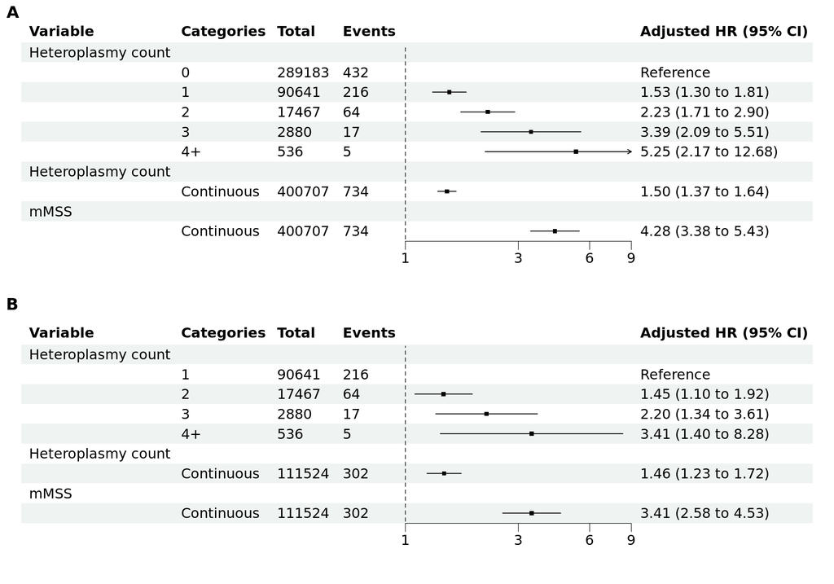

```r
combined <- ggpubr::ggarrange(p_hc_mss_all, p_hc_mss_het, labels = c("A", "B"), nrow = 2, ncol = 1, align = "v")
combined
```

```r
data <-
  data_all |>
  bind_rows(data_het) |>
  add_row(.before = 1) |>
  add_row(.before = 12) |>
  mutate(
    Panel = c("A", "", "", "", "", "", "", "", "", "", "", "B", "", "", "", "", "", "", "", "", "")
  ) |>
  dplyr::select(Panel, everything())

# Write the data to the sheets
openxlsx::writeData(wb, sheet = "Supplementary Figure 7", x = data)

# data |>
#   openxlsx::write.xlsx("ukb_mthet_chip_source_data_file.xlsx", sheetName = "Supplementary Figure 7", append = TRUE)
```

# 9 Supplementary Figure 8 - Hazard ratios (95% confidence intervals) for the association between heteroplasmy and incident MN by mtDNA complex / region.

## 9.1 Panel A

```r
hc_complex <-
  survival::coxph(surv ~ hetcount_complex_I + hetcount_complex_III + hetcount_complex_IV + hetcount_complex_V +
  hetcount_complex_DLOOP + hetcount_complex_RRNA + hetcount_complex_TRNA + rms::rcs(age, 5) + sex + smk_ever + prev_cancer_yn, data = ukb)
summary(hc_complex)
```

```
## Call:
## survival::coxph(formula = surv ~ hetcount_complex_I + hetcount_complex_III +
##     hetcount_complex_IV + hetcount_complex_V + hetcount_complex_DLOOP +
##     hetcount_complex_RRNA + hetcount_complex_TRNA + rms::rcs(age,
##     5) + sex + smk_ever + prev_cancer_yn, data = ukb)
##
##   n= 434304, number of events= 1191
##
##                            coef exp(coef) se(coef)      z Pr(>|z|)
## hetcount_complex_I      0.52519   1.69078  0.05996  8.759  < 2e-16 ***
## hetcount_complex_III    0.68303   1.97987  0.11510  5.934 2.95e-09 ***
## hetcount_complex_IV     0.56349   1.75680  0.08552  6.589 4.42e-11 ***
## hetcount_complex_V      0.70512   2.02409  0.12995  5.426 5.76e-08 ***
## hetcount_complex_DLOOP  0.10243   1.10786  0.08870  1.155   0.2482
## hetcount_complex_RRNA   0.82208   2.27522  0.08212 10.011  < 2e-16 ***
## hetcount_complex_TRNA   0.66745   1.94925  0.13267  5.031 4.88e-07 ***
## rms::rcs(age, 5)age     0.05958   1.06139  0.03431  1.737   0.0825 .
## rms::rcs(age, 5)age'    0.09734   1.10224  0.10745  0.906   0.3650
## rms::rcs(age, 5)age''  -0.49830   0.60757  0.41431 -1.203   0.2291
## rms::rcs(age, 5)age'''  1.30661   3.69362  0.76981  1.697   0.0896 .
## sexmen                  0.36971   1.44731  0.05887  6.280 3.39e-10 ***
## smk_everyes             0.14528   1.15636  0.06165  2.356   0.0185 *
## prev_cancer_yn          0.14757   1.15901  0.09744  1.514   0.1299
## ---
## Signif. codes:  0 '***' 0.001 '**' 0.01 '*' 0.05 '.' 0.1 ' ' 1
##
##                        exp(coef) exp(-coef) lower .95 upper .95
## hetcount_complex_I        1.6908     0.5914    1.5033     1.902
## hetcount_complex_III      1.9799     0.5051    1.5800     2.481
## hetcount_complex_IV       1.7568     0.5692    1.4857     2.077
## hetcount_complex_V        2.0241     0.4941    1.5690     2.611
## hetcount_complex_DLOOP    1.1079     0.9026    0.9311     1.318
## hetcount_complex_RRNA     2.2752     0.4395    1.9370     2.673
## hetcount_complex_TRNA     1.9493     0.5130    1.5029     2.528
## rms::rcs(age, 5)age       1.0614     0.9422    0.9924     1.135
## rms::rcs(age, 5)age'      1.1022     0.9072    0.8929     1.361
## rms::rcs(age, 5)age''     0.6076     1.6459    0.2697     1.369
## rms::rcs(age, 5)age'''    3.6936     0.2707    0.8169    16.700
## sexmen                    1.4473     0.6909    1.2896     1.624
## smk_everyes               1.1564     0.8648    1.0247     1.305
## prev_cancer_yn            1.1590     0.8628    0.9575     1.403
##
## Concordance= 0.718  (se = 0.007 )
## Likelihood ratio test= 815.5  on 14 df,   p=<2e-16
## Wald test            = 875.8  on 14 df,   p=<2e-16
## Score (logrank) test = 1001  on 14 df,   p=<2e-16
```

```r
hc <- summary(hc_complex)$coefficients[1:7, c(1:3, 5)] |>
  as.data.frame() |>
  rownames_to_column("Complex") |>
  mutate(
    Complex = case_when(
      grepl("hetcount_complex_V", Complex) ~ "Complex V",
      grepl("hetcount_complex_IV", Complex) ~ "Complex IV",
      grepl("hetcount_complex_III", Complex) ~ "Complex III",
      grepl("hetcount_complex_I", Complex) ~ "Complex I",
      grepl("DLOOP", Complex) ~ "D-loop",
      grepl("RRNA", Complex) ~ "rRNA",
      grepl("TRNA", Complex) ~ "tRNA"
    )
  )

hc
```

```
##       Complex      coef exp(coef)   se(coef)     Pr(>|z|)
## 1   Complex I 0.5251883  1.690777 0.05995941 1.968787e-18
## 2 Complex III 0.6830314  1.979870 0.11510167 2.953590e-09
## 3  Complex IV 0.5634914  1.756796 0.08551740 4.421981e-11
## 4   Complex V 0.7051179  2.024085 0.12995213 5.763686e-08
## 5      D-loop 0.1024267  1.107856 0.08870444 2.482148e-01
## 6        rRNA 0.8220765  2.275220 0.08211970 1.367668e-23
## 7        tRNA 0.6674468  1.949254 0.13267140 4.883697e-07
```

```r
p_hc_complex <- ggforestplot::forestplot(
  df = hc,
  name = Complex,
  estimate = coef,
  se = `se(coef)`,
  logodds = TRUE,
  xlab = "Hazard ratios (95% CI)",
  title = "Heteroplasmy count"
)
```

## 9.2 Panel B

```r
mss_complex <-
  survival::coxph(surv ~ mMSS_complex_I + mMSS_complex_III + mMSS_complex_IV + mMSS_complex_V +
  mMSS_complex_DLOOP + mMSS_complex_RRNA + mMSS_complex_TRNA + rms::rcs(age, 5) + sex + smk_ever + prev_cancer_yn, data = ukb)
summary(mss_complex)
```

```
## Call:
## survival::coxph(formula = surv ~ mMSS_complex_I + mMSS_complex_III +
##     mMSS_complex_IV + mMSS_complex_V + mMSS_complex_DLOOP + mMSS_complex_RRNA +
##     mMSS_complex_TRNA + rms::rcs(age, 5) + sex + smk_ever + prev_cancer_yn,
##     data = ukb)
##
##   n= 434304, number of events= 1191
##
##                            coef exp(coef) se(coef)      z Pr(>|z|)
## mMSS_complex_I          1.85534   6.39389  0.14623 12.688  < 2e-16 ***
## mMSS_complex_III        2.18435   8.88486  0.47721  4.577 4.71e-06 ***
## mMSS_complex_IV         1.82299   6.19036  0.16805 10.848  < 2e-16 ***
## mMSS_complex_V          2.04234   7.70866  1.17094  1.744   0.0811 .
## mMSS_complex_DLOOP      2.85472  17.36961  1.18039  2.418   0.0156 *
## mMSS_complex_RRNA       1.42961   4.17708  0.14228 10.048  < 2e-16 ***
## mMSS_complex_TRNA       2.06368   7.87490  0.30941  6.670 2.56e-11 ***
## rms::rcs(age, 5)age     0.05938   1.06118  0.03429  1.732   0.0833 .
## rms::rcs(age, 5)age'    0.09739   1.10229  0.10741  0.907   0.3646
## rms::rcs(age, 5)age''  -0.50497   0.60353  0.41420 -1.219   0.2228
## rms::rcs(age, 5)age'''  1.32402   3.75850  0.76981  1.720   0.0854 .
## sexmen                  0.36308   1.43776  0.05892  6.162 7.16e-10 ***
## smk_everyes             0.13877   1.14886  0.06172  2.248   0.0245 *
## prev_cancer_yn          0.13658   1.14635  0.09747  1.401   0.1611
## ---
## Signif. codes:  0 '***' 0.001 '**' 0.01 '*' 0.05 '.' 0.1 ' ' 1
##
##                        exp(coef) exp(-coef) lower .95 upper .95
## mMSS_complex_I            6.3939    0.15640    4.8006     8.516
## mMSS_complex_III          8.8849    0.11255    3.4870    22.639
## mMSS_complex_IV           6.1904    0.16154    4.4532     8.605
## mMSS_complex_V            7.7087    0.12972    0.7767    76.503
## mMSS_complex_DLOOP       17.3696    0.05757    1.7181   175.605
## mMSS_complex_RRNA         4.1771    0.23940    3.1605     5.521
## mMSS_complex_TRNA         7.8749    0.12699    4.2941    14.442
## rms::rcs(age, 5)age       1.0612    0.94235    0.9922     1.135
## rms::rcs(age, 5)age'      1.1023    0.90720    0.8930     1.361
## rms::rcs(age, 5)age''     0.6035    1.65693    0.2680     1.359
## rms::rcs(age, 5)age'''    3.7585    0.26606    0.8313    16.993
## sexmen                    1.4378    0.69553    1.2810     1.614
## smk_everyes               1.1489    0.87043    1.0180     1.297
## prev_cancer_yn            1.1463    0.87234    0.9470     1.388
##
## Concordance= 0.721  (se = 0.008 )
## Likelihood ratio test= 866.3  on 14 df,   p=<2e-16
## Wald test            = 1111  on 14 df,   p=<2e-16
## Score (logrank) test = 1386  on 14 df,   p=<2e-16
```

```r
mss <- summary(mss_complex)$coefficients[1:7, c(1:3, 5)] |>
  as.data.frame() |>
  rownames_to_column("Complex") |>
  mutate(
    Complex = case_when(
      grepl("mMSS_complex_V", Complex) ~ "Complex V",
      grepl("mMSS_complex_IV", Complex) ~ "Complex IV",
      grepl("mMSS_complex_III", Complex) ~ "Complex III",
      grepl("mMSS_complex_I", Complex) ~ "Complex I",
      grepl("DLOOP", Complex) ~ "D-loop",
      grepl("RRNA", Complex) ~ "rRNA",
      grepl("TRNA", Complex) ~ "tRNA"
    )
  )

mss
```

```
##       Complex     coef exp(coef)  se(coef)     Pr(>|z|)
## 1   Complex I 1.855343  6.393890 0.1462261 6.876291e-37
## 2 Complex III 2.184349  8.884863 0.4772112 4.709682e-06
## 3  Complex IV 1.822993  6.190356 0.1680509 2.041470e-27
## 4   Complex V 2.042344  7.708655 1.1709358 8.112458e-02
## 5      D-loop 2.854722 17.369613 1.1803870 1.558623e-02
## 6        rRNA 1.429612  4.177077 0.1422839 9.413076e-24
## 7        tRNA 2.063680  7.874899 0.3094135 2.564124e-11
```

```r
p_mss_complex <- ggforestplot::forestplot(
  df = mss,
  name = Complex,
  estimate = coef,
  se = `se(coef)`,
  logodds = TRUE,
  xlab = "Hazard ratios (95% CI)",
  title = "mMSS"
)
```

## 9.3 Combined

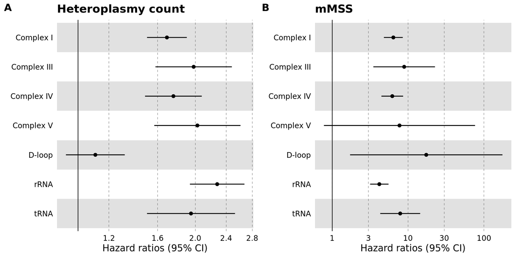

```r
combined <- ggpubr::ggarrange(p_hc_complex, p_mss_complex, nrow = 1, labels = c("A", "B"), widths = c(1, 1))
combined
```

```r
data <-
  hc |>
  bind_rows(mss)|>
  add_row(.before = 1) |>
  add_row(.before = 9) |>
  mutate(
    Panel = c("A", "", "", "", "", "", "", "", "B", "", "", "", "", "", "", ""),
    Metric = c("Heteroplasmy count", "", "", "", "", "", "", "", "mMSS", "", "", "", "", "", "", "")
  ) |>
  dplyr::select(Panel, Metric, everything())

# Write the data to the sheets
openxlsx::writeData(wb, sheet = "Supplementary Figure 8", x = data)

# Export the file
openxlsx::saveWorkbook(wb, "ukb_mthet_chip_source_data_file_02_survival.xlsx", overwrite = TRUE)

# data |>
#   openxlsx::write.xlsx("ukb_mthet_chip_source_data_file.xlsx", sheetName = "Supplementary Figure 8", append = TRUE)
```

# 10 Supplementary Figure 10 - Cumulative incidence and hazard ratios (95% confidence intervals) of MN by CHRS category.

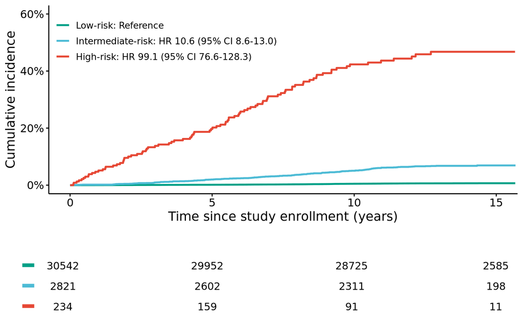

```r
km <- survfit(surv_chip ~ chrs_cat, data = ukb_chip)

plot_chip <- survminer::ggsurvplot(
  km,
  censor = FALSE,
  risk.table = TRUE,
  risk.table.y.text = F,
  risk.table.y.text.col = T,
  risk.table.title = "",
  fontsize = 4,
  risk.table.height = 0.3,
  tables.theme = theme_cleantable(),
  fun = "event",
  xlim = c(0, 15),
  ylim = c(0, 0.60),
  break.time.by = 5,
  surv.scale = "percent",
  legend.title = "",
  font.legend = c(10, "black"),
  legend = c(0.25, 0.85),
  legend.lab =
    c("Low-risk: Reference",
      "Intermediate-risk: HR 10.6 (95% CI 8.6-13.0)",
      "High-risk: HR 99.1 (95% CI 76.6-128.3)"),
  xlab = "Time since study enrollment (years)",
  ylab = "Cumulative incidence",
  palette = c("#00A087FF", "#4DBBD5FF", "#E64835FF")
 )
plot_chip
```

```r
survival::coxph(surv_chip ~ chrs_cat + sex + smk_ever + prev_cancer_yn, data = ukb_chip) |>
  summary()
```

```
## Call:
## survival::coxph(formula = surv_chip ~ chrs_cat + sex + smk_ever +
##     prev_cancer_yn, data = ukb_chip)
##
##   n= 33597, number of events= 457
##
##                          coef exp(coef) se(coef)      z Pr(>|z|)
## chrs_catintermediate  2.35831  10.57310  0.10496 22.469   <2e-16 ***
## chrs_cathigh          4.59655  99.14203  0.13156 34.940   <2e-16 ***
## sexmen                0.26777   1.30705  0.09726  2.753   0.0059 **
## smk_everyes           0.10167   1.10702  0.10189  0.998   0.3183
## prev_cancer_yn       -0.24096   0.78587  0.16625 -1.449   0.1472
## ---
## Signif. codes:  0 '***' 0.001 '**' 0.01 '*' 0.05 '.' 0.1 ' ' 1
##
##                      exp(coef) exp(-coef) lower .95 upper .95
## chrs_catintermediate   10.5731    0.09458    8.6072    12.988
## chrs_cathigh           99.1420    0.01009   76.6083   128.304
## sexmen                  1.3070    0.76508    1.0802     1.582
## smk_everyes             1.1070    0.90332    0.9066     1.352
## prev_cancer_yn          0.7859    1.27247    0.5673     1.089
##
## Concordance= 0.767  (se = 0.014 )
## Likelihood ratio test= 961.4  on 5 df,   p=<2e-16
## Wald test            = 1416  on 5 df,   p=<2e-16
## Score (logrank) test = 4791  on 5 df,   p=<2e-16
```